# Association

Run Calculating_BA.Rmd first

### Association between BA and ADRD

Prepare variables, recoding DispInk and UtbNiva

```r
# Calculate median and IQR
median_income <- median(to1po2$DispInk, na.rm = TRUE)
iqr_income <- IQR(to1po2$DispInk, na.rm = TRUE)

# Define breaks based on median and IQR
# Adjust these values as needed to better categorize your data
lower_break <- median_income - iqr_income
upper_break <- median_income + iqr_income

breaks <- c(-Inf, lower_break, upper_break, Inf)

labels <- c("Low Income", "Middle Income", "High Income")

to1po2 <- to1po2 %>%
  mutate(
    income_bins = cut(DispInk, breaks = breaks, labels = labels, include.lowest = TRUE),
    income_bins = factor(income_bins, levels = labels)  # Set the levels to maintain order
  )

# Set 'Middle Income' as the reference category
to1po2$income_bins <- relevel(to1po2$income_bins, ref = "Middle Income")

# Check the distribution of the new bins
table(to1po2$income_bins)
```

```
Middle Income    Low Income   High Income
        52527          5816          9033
```

```r
# Education level
#to1po2$UtbNiva <- factor(to1po2$UtbNiva)
#to1po2$UtbNiva <- relevel(to1po2$UtbNiva, ref = "4")
to1po2 <- to1po2 %>%
  mutate(NewUtbNiva = case_when(
    UtbNiva %in% c('1', '2', '3') ~ '1',
    UtbNiva %in% c('4', '5', '6', '7') ~ '2',
    TRUE ~ NA_character_  # For empty or unknown levels
  )) %>%
  mutate(NewUtbNiva = fct_explicit_na(factor(NewUtbNiva, levels = c('1', '2')), na_level = "NA"))


# Calculate age at FirstDate in years
to1po2$AgeAtFirstDate <- as.numeric(difftime(to1po2$firstDate, to1po2$FODDATn, units = "days") / 365.25)
# Calculate age at LastDate in years
to1po2$AgeAtLastDate <- as.numeric(difftime(to1po2$lastDate, to1po2$FODDATn, units = "days") / 365.25)
```

#======== Association with ADRD and subtypes ADRD

```r
# BA measures to be tested
BA_measures <- c("kdm_res", "phenoage_res", "hd_log_res")

# Correct the initialization of HR_BA data frame
HR_BA_adrd <- data.frame(
  BA = rep(BA_measures, each = 2),  # Repeat each BA measure twice
  outcome = rep("ADRD", times = length(BA_measures) * 2),
  model = rep(c("Sex-adjusted model", "Multivariable model"), times = length(BA_measures)),
  beta = NA, se = NA, HR = NA, lb = NA, ub = NA, p = NA, p_PH_BA = NA, global_p_PH_BA = NA,
  concordance = NA, N = NA  # Add a column for the concordance index
)

for (j in 1:length(BA_measures)) {
  # Sex-adjusted model
  fit_gender <- coxph(as.formula(paste("Surv(AgeAtFirstDate, AgeAtLastDate, ADRD) ~", BA_measures[j], "+ gender")), data = to1po2)
  coef_gender <- summary(fit_gender)
  row_index_gender <- (j * 2) - 1
  HR_BA_adrd[row_index_gender, c(4, 5, 9, 12)] <- c(coef_gender$coefficients[1, c(1, 3, 5)], coef_gender$concordance[1])
  HR_BA_adrd[row_index_gender, 6:8] <- coef_gender$conf.int[1, c(1, 3, 4)]
  HR_BA_adrd[row_index_gender, 10] <- cox.zph(fit_gender)$table[1, 3]
  HR_BA_adrd[row_index_gender, 11] <- cox.zph(fit_gender)$table[3, 3]
  HR_BA_adrd[row_index_gender, "N"] <- coef_gender$n

  # Multivariable model
  fit_multivariable <- coxph(as.formula(paste("Surv(AgeAtFirstDate, AgeAtLastDate, ADRD) ~", BA_measures[j], "+ gender + income_bins + NewUtbNiva")), data = to1po2)
  coef_multivariable <- summary(fit_multivariable)
  row_index_multivariable <- j * 2
  HR_BA_adrd[row_index_multivariable, c(4, 5, 9, 12)] <- c(coef_multivariable$coefficients[1, c(1, 3, 5)], coef_multivariable$concordance[1])
  HR_BA_adrd[row_index_multivariable, 6:8] <- coef_multivariable$conf.int[1, c(1, 3, 4)]
  HR_BA_adrd[row_index_multivariable, 10] <- cox.zph(fit_multivariable)$table[1, 3]
  HR_BA_adrd[row_index_multivariable, 11] <- cox.zph(fit_multivariable)$table[3, 3]
  HR_BA_adrd[row_index_multivariable, "N"] <- coef_multivariable$n
}

ADRD_results <- HR_BA_adrd

# Print the modified HR_BA_adrd data frame
print(HR_BA_adrd)
```

ADRD based on SveDem

```r
# BA measures to be tested
BA_measures <- c("kdm_res", "phenoage_res", "hd_log_res")

# Correct the initialization of HR_BA_adrd data frame
HR_BA_s_adrd <- data.frame(
  BA = rep(BA_measures, each = 2),  # Repeat each BA measure twice
  outcome = rep("SveDem ADRD", times = length(BA_measures) * 2),
  model = rep(c("Sex-adjusted model", "Multivariable model"), times = length(BA_measures)),
  beta = NA, se = NA, HR = NA, lb = NA, ub = NA, p = NA, p_PH_BA = NA, global_p_PH_BA = NA,
  concordance = NA, N=NA  # Add a column for the concordance index
)

for (j in 1:length(BA_measures)) {
  # Sex-adjusted model
  fit_gender <- coxph(as.formula(paste("Surv(AgeAtFirstDate, AgeAtLastDate, S_ADRD) ~", BA_measures[j], "+ gender")), data = to1po2)
  coef_gender <- summary(fit_gender)
  row_index_gender <- (j * 2) - 1
  HR_BA_s_adrd[row_index_gender, c(4, 5, 9, 12)] <- c(coef_gender$coefficients[1, c(1, 3, 5)], coef_gender$concordance[1])
  HR_BA_s_adrd[row_index_gender, 6:8] <- coef_gender$conf.int[1, c(1, 3, 4)]
  HR_BA_s_adrd[row_index_gender, 10] <- cox.zph(fit_gender)$table[1, 3]
  HR_BA_s_adrd[row_index_gender, 11] <- cox.zph(fit_gender)$table[3, 3]
  HR_BA_s_adrd[row_index_gender, "N"] <- coef_gender$n

  # Multivariable model
  fit_multivariable <- coxph(as.formula(paste("Surv(AgeAtFirstDate, AgeAtLastDate, S_ADRD) ~", BA_measures[j], "+ gender + income_bins + NewUtbNiva")), data = to1po2)
  coef_multivariable <- summary(fit_multivariable)
  row_index_multivariable <- j * 2
  HR_BA_s_adrd[row_index_multivariable, c(4, 5, 9, 12)] <- c(coef_multivariable$coefficients[1, c(1, 3, 5)], coef_multivariable$concordance[1])
  HR_BA_s_adrd[row_index_multivariable, 6:8] <- coef_multivariable$conf.int[1, c(1, 3, 4)]
  HR_BA_s_adrd[row_index_multivariable, 10] <- cox.zph(fit_multivariable)$table[1, 3]
  HR_BA_s_adrd[row_index_multivariable, 11] <- cox.zph(fit_multivariable)$table[3, 3]
  HR_BA_s_adrd[row_index_multivariable, "N"] <- coef_multivariable$n
}

S_ADRD_results <- HR_BA_s_adrd

# Print the modified HR_BA_adrd data frame
print(HR_BA_s_adrd)
```

ADRD excluding SveDem

```r
# BA measures to be tested
BA_measures <- c("kdm_res", "phenoage_res", "hd_log_res")

# Correct the initialization of HR_BA_adrd data frame
HR_BA_ns_adrd <- data.frame(
  BA = rep(BA_measures, each = 2),  # Repeat each BA measure twice
  outcome = rep("Excluding SveDem ADRD", times = length(BA_measures) * 2),
  model = rep(c("Sex-adjusted model", "Multivariable model"), times = length(BA_measures)),
  beta = NA, se = NA, HR = NA, lb = NA, ub = NA, p = NA, p_PH_BA = NA, global_p_PH_BA = NA,
  concordance = NA, N=NA  # Add a column for the concordance index
)

for (j in 1:length(BA_measures)) {
  # Sex-adjusted model
  fit_gender <- coxph(as.formula(paste("Surv(AgeAtFirstDate, AgeAtLastDate, NS_ADRD) ~", BA_measures[j], "+ gender")), data = to1po2)
  coef_gender <- summary(fit_gender)
  row_index_gender <- (j * 2) - 1
  HR_BA_ns_adrd[row_index_gender, c(4, 5, 9, 12)] <- c(coef_gender$coefficients[1, c(1, 3, 5)], coef_gender$concordance[1])
  HR_BA_ns_adrd[row_index_gender, 6:8] <- coef_gender$conf.int[1, c(1, 3, 4)]
  HR_BA_ns_adrd[row_index_gender, 10] <- cox.zph(fit_gender)$table[1, 3]
  HR_BA_ns_adrd[row_index_gender, 11] <- cox.zph(fit_gender)$table[3, 3]
  HR_BA_ns_adrd[row_index_gender, "N"] <- coef_gender$n

  # Multivariable model
  fit_multivariable <- coxph(as.formula(paste("Surv(AgeAtFirstDate, AgeAtLastDate, NS_ADRD) ~", BA_measures[j], "+ gender + income_bins + NewUtbNiva")), data = to1po2)
  coef_multivariable <- summary(fit_multivariable)
  row_index_multivariable <- j * 2
  HR_BA_ns_adrd[row_index_multivariable, c(4, 5, 9, 12)] <- c(coef_multivariable$coefficients[1, c(1, 3, 5)], coef_multivariable$concordance[1])
  HR_BA_ns_adrd[row_index_multivariable, 6:8] <- coef_multivariable$conf.int[1, c(1, 3, 4)]
  HR_BA_ns_adrd[row_index_multivariable, 10] <- cox.zph(fit_multivariable)$table[1, 3]
  HR_BA_ns_adrd[row_index_multivariable, 11] <- cox.zph(fit_multivariable)$table[3, 3]
  HR_BA_ns_adrd[row_index_multivariable, "N"] <- coef_multivariable$n
}

NS_ADRD_results <- HR_BA_ns_adrd

# Print the modified HR_BA_adrd data frame
print(HR_BA_ns_adrd)
```

Alzheimers broad category ie not SveDem

```r
# BA measures to be tested
BA_measures <- c("kdm_res", "phenoage_res", "hd_log_res")

# Correct the initialization of HR_BA_adrd data frame
HR_BA_alzh <- data.frame(
  BA = rep(BA_measures, each = 2),  # Repeat each BA measure twice
  outcome = rep("Alzheimers", times = length(BA_measures) * 2),
  model = rep(c("Sex-adjusted model", "Multivariable model"), times = length(BA_measures)),
  beta = NA, se = NA, HR = NA, lb = NA, ub = NA, p = NA, p_PH_BA = NA, global_p_PH_BA = NA,
  concordance = NA, N=NA  # Add a column for the concordance index
)

for (j in 1:length(BA_measures)) {
  # Sex-adjusted model
  fit_gender <- coxph(as.formula(paste("Surv(AgeAtFirstDate, AgeAtLastDate, Alzheimers) ~", BA_measures[j], "+ gender")), data = to1po2)
  coef_gender <- summary(fit_gender)
  row_index_gender <- (j * 2) - 1
  HR_BA_alzh[row_index_gender, c(4, 5, 9, 12)] <- c(coef_gender$coefficients[1, c(1, 3, 5)], coef_gender$concordance[1])
  HR_BA_alzh[row_index_gender, 6:8] <- coef_gender$conf.int[1, c(1, 3, 4)]
  HR_BA_alzh[row_index_gender, 10] <- cox.zph(fit_gender)$table[1, 3]
  HR_BA_alzh[row_index_gender, 11] <- cox.zph(fit_gender)$table[3, 3]
  HR_BA_alzh[row_index_gender, "N"] <- coef_gender$n

  # Multivariable model
  fit_multivariable <- coxph(as.formula(paste("Surv(AgeAtFirstDate, AgeAtLastDate, Alzheimers) ~", BA_measures[j], "+ gender + income_bins + NewUtbNiva")), data = to1po2)
  coef_multivariable <- summary(fit_multivariable)
  row_index_multivariable <- j * 2
  HR_BA_alzh[row_index_multivariable, c(4, 5, 9, 12)] <- c(coef_multivariable$coefficients[1, c(1, 3, 5)], coef_multivariable$concordance[1])
  HR_BA_alzh[row_index_multivariable, 6:8] <- coef_multivariable$conf.int[1, c(1, 3, 4)]
  HR_BA_alzh[row_index_multivariable, 10] <- cox.zph(fit_multivariable)$table[1, 3]
  HR_BA_alzh[row_index_multivariable, 11] <- cox.zph(fit_multivariable)$table[3, 3]
  HR_BA_alzh[row_index_multivariable, "N"] <- coef_multivariable$n
}

Alzh_results <- HR_BA_alzh

# Print the modified HR_BA_adrd data frame
print(HR_BA_alzh)
```

SveDem Alzheimers

```r
# BA measures to be tested
BA_measures <- c("kdm_res", "phenoage_res", "hd_log_res")

# Correct the initialization of HR_BA_adrd data frame
HR_BA_s_alzh <- data.frame(
  BA = rep(BA_measures, each = 2),  # Repeat each BA measure twice
  outcome = rep("SveDem Alzheimers", times = length(BA_measures) * 2),
  model = rep(c("Sex-adjusted model", "Multivariable model"), times = length(BA_measures)),
  beta = NA, se = NA, HR = NA, lb = NA, ub = NA, p = NA, p_PH_BA = NA, global_p_PH_BA = NA,
  concordance = NA, N=NA  # Add a column for the concordance index
)

for (j in 1:length(BA_measures)) {
  # Sex-adjusted model
  fit_gender <- coxph(as.formula(paste("Surv(AgeAtFirstDate, AgeAtLastDate, S_Alzheimers) ~", BA_measures[j], "+ gender")), data = to1po2)
  coef_gender <- summary(fit_gender)
  row_index_gender <- (j * 2) - 1
  HR_BA_s_alzh[row_index_gender, c(4, 5, 9, 12)] <- c(coef_gender$coefficients[1, c(1, 3, 5)], coef_gender$concordance[1])
  HR_BA_s_alzh[row_index_gender, 6:8] <- coef_gender$conf.int[1, c(1, 3, 4)]
  HR_BA_s_alzh[row_index_gender, 10] <- cox.zph(fit_gender)$table[1, 3]
  HR_BA_s_alzh[row_index_gender, 11] <- cox.zph(fit_gender)$table[3, 3]
  HR_BA_s_alzh[row_index_gender, "N"] <- coef_gender$n

  # Multivariable model
  fit_multivariable <- coxph(as.formula(paste("Surv(AgeAtFirstDate, AgeAtLastDate, S_Alzheimers) ~", BA_measures[j], "+ gender + income_bins + NewUtbNiva")), data = to1po2)
  coef_multivariable <- summary(fit_multivariable)
  row_index_multivariable <- j * 2
  HR_BA_s_alzh[row_index_multivariable, c(4, 5, 9, 12)] <- c(coef_multivariable$coefficients[1, c(1, 3, 5)], coef_multivariable$concordance[1])
  HR_BA_s_alzh[row_index_multivariable, 6:8] <- coef_multivariable$conf.int[1, c(1, 3, 4)]
  HR_BA_s_alzh[row_index_multivariable, 10] <- cox.zph(fit_multivariable)$table[1, 3]
  HR_BA_s_alzh[row_index_multivariable, 11] <- cox.zph(fit_multivariable)$table[3, 3]
  HR_BA_s_alzh[row_index_multivariable, "N"] <- coef_multivariable$n
}

S_Alzh_results <- HR_BA_s_alzh

# Print the modified HR_BA_adrd data frame
print(HR_BA_s_alzh)
```

Alzheimers excluding SveDem

```r
# BA measures to be tested
BA_measures <- c("kdm_res", "phenoage_res", "hd_log_res")

# Correct the initialization of HR_BA_adrd data frame
HR_BA_ns_alzh <- data.frame(
  BA = rep(BA_measures, each = 2),  # Repeat each BA measure twice
  outcome = rep("Excluding SveDem Alzheimers", times = length(BA_measures) * 2),
  model = rep(c("Sex-adjusted model", "Multivariable model"), times = length(BA_measures)),
  beta = NA, se = NA, HR = NA, lb = NA, ub = NA, p = NA, p_PH_BA = NA, global_p_PH_BA = NA,
  concordance = NA, N=NA  # Add a column for the concordance index
)

for (j in 1:length(BA_measures)) {
  # Sex-adjusted model
  fit_gender <- coxph(as.formula(paste("Surv(AgeAtFirstDate, AgeAtLastDate, NS_Alzheimers) ~", BA_measures[j], "+ gender")), data = to1po2)
  coef_gender <- summary(fit_gender)
  row_index_gender <- (j * 2) - 1
  HR_BA_ns_alzh[row_index_gender, c(4, 5, 9, 12)] <- c(coef_gender$coefficients[1, c(1, 3, 5)], coef_gender$concordance[1])
  HR_BA_ns_alzh[row_index_gender, 6:8] <- coef_gender$conf.int[1, c(1, 3, 4)]
  HR_BA_ns_alzh[row_index_gender, 10] <- cox.zph(fit_gender)$table[1, 3]
  HR_BA_ns_alzh[row_index_gender, 11] <- cox.zph(fit_gender)$table[3, 3]
  HR_BA_ns_alzh[row_index_gender, "N"] <- coef_gender$n

  # Multivariable model
  fit_multivariable <- coxph(as.formula(paste("Surv(AgeAtFirstDate, AgeAtLastDate, NS_Alzheimers) ~", BA_measures[j], "+ gender + income_bins + NewUtbNiva")), data = to1po2)
  coef_multivariable <- summary(fit_multivariable)
  row_index_multivariable <- j * 2
  HR_BA_ns_alzh[row_index_multivariable, c(4, 5, 9, 12)] <- c(coef_multivariable$coefficients[1, c(1, 3, 5)], coef_multivariable$concordance[1])
  HR_BA_ns_alzh[row_index_multivariable, 6:8] <- coef_multivariable$conf.int[1, c(1, 3, 4)]
  HR_BA_ns_alzh[row_index_multivariable, 10] <- cox.zph(fit_multivariable)$table[1, 3]
  HR_BA_ns_alzh[row_index_multivariable, 11] <- cox.zph(fit_multivariable)$table[3, 3]
  HR_BA_ns_alzh[row_index_multivariable, "N"] <- coef_multivariable$n
}

NS_Alzh_results <- HR_BA_ns_alzh

# Print the modified HR_BA_adrd data frame
print(HR_BA_ns_alzh)
```

Vascular

```r
# BA measures to be tested
BA_measures <- c("kdm_res", "phenoage_res", "hd_log_res")

# Correct the initialization of HR_BA_adrd data frame
HR_BA_vasc <- data.frame(
  BA = rep(BA_measures, each = 2),  # Repeat each BA measure twice
  outcome = rep("Vascular Dementia", times = length(BA_measures) * 2),
  model = rep(c("Sex-adjusted model", "Multivariable model"), times = length(BA_measures)),
  beta = NA, se = NA, HR = NA, lb = NA, ub = NA, p = NA, p_PH_BA = NA, global_p_PH_BA = NA,
  concordance = NA, N=NA  # Add a column for the concordance index
)

for (j in 1:length(BA_measures)) {
  # Sex-adjusted model
  fit_gender <- coxph(as.formula(paste("Surv(AgeAtFirstDate, AgeAtLastDate, Vascular) ~", BA_measures[j], "+ gender")), data = to1po2)
  coef_gender <- summary(fit_gender)
  row_index_gender <- (j * 2) - 1
  HR_BA_vasc[row_index_gender, c(4, 5, 9, 12)] <- c(coef_gender$coefficients[1, c(1, 3, 5)], coef_gender$concordance[1])
  HR_BA_vasc[row_index_gender, 6:8] <- coef_gender$conf.int[1, c(1, 3, 4)]
  HR_BA_vasc[row_index_gender, 10] <- cox.zph(fit_gender)$table[1, 3]
  HR_BA_vasc[row_index_gender, 11] <- cox.zph(fit_gender)$table[3, 3]
  HR_BA_vasc[row_index_gender, "N"] <- coef_gender$n

  # Multivariable model
  fit_multivariable <- coxph(as.formula(paste("Surv(AgeAtFirstDate, AgeAtLastDate, Vascular) ~", BA_measures[j], "+ gender + income_bins + NewUtbNiva")), data = to1po2)
  coef_multivariable <- summary(fit_multivariable)
  row_index_multivariable <- j * 2
  HR_BA_vasc[row_index_multivariable, c(4, 5, 9, 12)] <- c(coef_multivariable$coefficients[1, c(1, 3, 5)], coef_multivariable$concordance[1])
  HR_BA_vasc[row_index_multivariable, 6:8] <- coef_multivariable$conf.int[1, c(1, 3, 4)]
  HR_BA_vasc[row_index_multivariable, 10] <- cox.zph(fit_multivariable)$table[1, 3]
  HR_BA_vasc[row_index_multivariable, 11] <- cox.zph(fit_multivariable)$table[3, 3]
  HR_BA_vasc[row_index_multivariable, "N"] <- coef_multivariable$n
}

Vasc_results <- HR_BA_vasc

# Print the modified HR_BA_adrd data frame
print(HR_BA_vasc)
```

Svedem Vascular

```r
# BA measures to be tested
BA_measures <- c("kdm_res", "phenoage_res", "hd_log_res")

# Correct the initialization of HR_BA_adrd data frame
HR_BA_s_vasc <- data.frame(
  BA = rep(BA_measures, each = 2),  # Repeat each BA measure twice
  outcome = rep("SveDem Vascular Dementia", times = length(BA_measures) * 2),
  model = rep(c("Sex-adjusted model", "Multivariable model"), times = length(BA_measures)),
  beta = NA, se = NA, HR = NA, lb = NA, ub = NA, p = NA, p_PH_BA = NA, global_p_PH_BA = NA,
  concordance = NA, N=NA  # Add a column for the concordance index
)

for (j in 1:length(BA_measures)) {
  # Sex-adjusted model
  fit_gender <- coxph(as.formula(paste("Surv(AgeAtFirstDate, AgeAtLastDate, S_Vascular) ~", BA_measures[j], "+ gender")), data = to1po2)
  coef_gender <- summary(fit_gender)
  row_index_gender <- (j * 2) - 1
  HR_BA_s_vasc[row_index_gender, c(4, 5, 9, 12)] <- c(coef_gender$coefficients[1, c(1, 3, 5)], coef_gender$concordance[1])
  HR_BA_s_vasc[row_index_gender, 6:8] <- coef_gender$conf.int[1, c(1, 3, 4)]
  HR_BA_s_vasc[row_index_gender, 10] <- cox.zph(fit_gender)$table[1, 3]
  HR_BA_s_vasc[row_index_gender, 11] <- cox.zph(fit_gender)$table[3, 3]
  HR_BA_s_vasc[row_index_gender, "N"] <- coef_gender$n

  # Multivariable model
  fit_multivariable <- coxph(as.formula(paste("Surv(AgeAtFirstDate, AgeAtLastDate, S_Vascular) ~", BA_measures[j], "+ gender + income_bins + NewUtbNiva")), data = to1po2)
  coef_multivariable <- summary(fit_multivariable)
  row_index_multivariable <- j * 2
  HR_BA_s_vasc[row_index_multivariable, c(4, 5, 9, 12)] <- c(coef_multivariable$coefficients[1, c(1, 3, 5)], coef_multivariable$concordance[1])
  HR_BA_s_vasc[row_index_multivariable, 6:8] <- coef_multivariable$conf.int[1, c(1, 3, 4)]
  HR_BA_s_vasc[row_index_multivariable, 10] <- cox.zph(fit_multivariable)$table[1, 3]
  HR_BA_s_vasc[row_index_multivariable, 11] <- cox.zph(fit_multivariable)$table[3, 3]
  HR_BA_s_vasc[row_index_multivariable, "N"] <- coef_multivariable$n
}

S_Vasc_results <- HR_BA_s_vasc

# Print the modified HR_BA_adrd data frame
print(HR_BA_s_vasc)
```

Exluding SveDem Vascular

```r
# BA measures to be tested
BA_measures <- c("kdm_res", "phenoage_res", "hd_log_res")

# Correct the initialization of HR_BA_adrd data frame
HR_BA_ns_vasc <- data.frame(
  BA = rep(BA_measures, each = 2),  # Repeat each BA measure twice
  outcome = rep("Excluding SveDem Vascular Dementia", times = length(BA_measures) * 2),
  model = rep(c("Sex-adjusted model", "Multivariable model"), times = length(BA_measures)),
  beta = NA, se = NA, HR = NA, lb = NA, ub = NA, p = NA, p_PH_BA = NA, global_p_PH_BA = NA,
  concordance = NA, N=NA  # Add a column for the concordance index
)

for (j in 1:length(BA_measures)) {
  # Sex-adjusted model
  fit_gender <- coxph(as.formula(paste("Surv(AgeAtFirstDate, AgeAtLastDate, NS_Vascular) ~", BA_measures[j], "+ gender")), data = to1po2)
  coef_gender <- summary(fit_gender)
  row_index_gender <- (j * 2) - 1
  HR_BA_ns_vasc[row_index_gender, c(4, 5, 9, 12)] <- c(coef_gender$coefficients[1, c(1, 3, 5)], coef_gender$concordance[1])
  HR_BA_ns_vasc[row_index_gender, 6:8] <- coef_gender$conf.int[1, c(1, 3, 4)]
  HR_BA_ns_vasc[row_index_gender, 10] <- cox.zph(fit_gender)$table[1, 3]
  HR_BA_ns_vasc[row_index_gender, 11] <- cox.zph(fit_gender)$table[3, 3]
  HR_BA_ns_vasc[row_index_gender, "N"] <- coef_gender$n

  # Multivariable model
  fit_multivariable <- coxph(as.formula(paste("Surv(AgeAtFirstDate, AgeAtLastDate, NS_Vascular) ~", BA_measures[j], "+ gender + income_bins + NewUtbNiva")), data = to1po2)
  coef_multivariable <- summary(fit_multivariable)
  row_index_multivariable <- j * 2
  HR_BA_ns_vasc[row_index_multivariable, c(4, 5, 9, 12)] <- c(coef_multivariable$coefficients[1, c(1, 3, 5)], coef_multivariable$concordance[1])
  HR_BA_ns_vasc[row_index_multivariable, 6:8] <- coef_multivariable$conf.int[1, c(1, 3, 4)]
  HR_BA_ns_vasc[row_index_multivariable, 10] <- cox.zph(fit_multivariable)$table[1, 3]
  HR_BA_ns_vasc[row_index_multivariable, 11] <- cox.zph(fit_multivariable)$table[3, 3]
  HR_BA_ns_vasc[row_index_multivariable, "N"] <- coef_multivariable$n
}

NS_Vasc_results <- HR_BA_ns_vasc

# Print the modified HR_BA_adrd data frame
print(HR_BA_ns_vasc)
```

Other

```r
# BA measures to be tested
BA_measures <- c("kdm_res", "phenoage_res", "hd_log_res")

# Correct the initialization of HR_BA_adrd data frame
HR_BA_othe <- data.frame(
  BA = rep(BA_measures, each = 2),  # Repeat each BA measure twice
  outcome = rep("Other Dementia", times = length(BA_measures) * 2),
  model = rep(c("Sex-adjusted model", "Multivariable model"), times = length(BA_measures)),
  beta = NA, se = NA, HR = NA, lb = NA, ub = NA, p = NA, p_PH_BA = NA, global_p_PH_BA = NA,
  concordance = NA, N=NA  # Add a column for the concordance index
)

for (j in 1:length(BA_measures)) {
  # Sex-adjusted model
  fit_gender <- coxph(as.formula(paste("Surv(AgeAtFirstDate, AgeAtLastDate, Other) ~", BA_measures[j], "+ gender")), data = to1po2)
  coef_gender <- summary(fit_gender)
  row_index_gender <- (j * 2) - 1
  HR_BA_othe[row_index_gender, c(4, 5, 9, 12)] <- c(coef_gender$coefficients[1, c(1, 3, 5)], coef_gender$concordance[1])
  HR_BA_othe[row_index_gender, 6:8] <- coef_gender$conf.int[1, c(1, 3, 4)]
  HR_BA_othe[row_index_gender, 10] <- cox.zph(fit_gender)$table[1, 3]
  HR_BA_othe[row_index_gender, 11] <- cox.zph(fit_gender)$table[3, 3]
  HR_BA_othe[row_index_gender, "N"] <- coef_gender$n

  # Multivariable model
  fit_multivariable <- coxph(as.formula(paste("Surv(AgeAtFirstDate, AgeAtLastDate, Other) ~", BA_measures[j], "+ gender + income_bins + NewUtbNiva")), data = to1po2)
  coef_multivariable <- summary(fit_multivariable)
  row_index_multivariable <- j * 2
  HR_BA_othe[row_index_multivariable, c(4, 5, 9, 12)] <- c(coef_multivariable$coefficients[1, c(1, 3, 5)], coef_multivariable$concordance[1])
  HR_BA_othe[row_index_multivariable, 6:8] <- coef_multivariable$conf.int[1, c(1, 3, 4)]
  HR_BA_othe[row_index_multivariable, 10] <- cox.zph(fit_multivariable)$table[1, 3]
  HR_BA_othe[row_index_multivariable, 11] <- cox.zph(fit_multivariable)$table[3, 3]
  HR_BA_othe[row_index_multivariable, "N"] <- coef_multivariable$n
}

Othe_results <- HR_BA_othe

# Print the modified HR_BA_adrd data frame
print(HR_BA_othe)
```

SveDem Other

```r
# BA measures to be tested
BA_measures <- c("kdm_res", "phenoage_res", "hd_log_res")

# Correct the initialization of HR_BA_adrd data frame
HR_BA_s_othe <- data.frame(
  BA = rep(BA_measures, each = 2),  # Repeat each BA measure twice
  outcome = rep("SveDem Other Dementia", times = length(BA_measures) * 2),
  model = rep(c("Sex-adjusted model", "Multivariable model"), times = length(BA_measures)),
  beta = NA, se = NA, HR = NA, lb = NA, ub = NA, p = NA, p_PH_BA = NA, global_p_PH_BA = NA,
  concordance = NA, N=NA  # Add a column for the concordance index
)

for (j in 1:length(BA_measures)) {
  # Sex-adjusted model
  fit_gender <- coxph(as.formula(paste("Surv(AgeAtFirstDate, AgeAtLastDate, S_other) ~", BA_measures[j], "+ gender")), data = to1po2)
  coef_gender <- summary(fit_gender)
  row_index_gender <- (j * 2) - 1
  HR_BA_s_othe[row_index_gender, c(4, 5, 9, 12)] <- c(coef_gender$coefficients[1, c(1, 3, 5)], coef_gender$concordance[1])
  HR_BA_s_othe[row_index_gender, 6:8] <- coef_gender$conf.int[1, c(1, 3, 4)]
  HR_BA_s_othe[row_index_gender, 10] <- cox.zph(fit_gender)$table[1, 3]
  HR_BA_s_othe[row_index_gender, 11] <- cox.zph(fit_gender)$table[3, 3]
  HR_BA_s_othe[row_index_gender, "N"] <- coef_gender$n

  # Multivariable model
  fit_multivariable <- coxph(as.formula(paste("Surv(AgeAtFirstDate, AgeAtLastDate, S_other) ~", BA_measures[j], "+ gender + income_bins + NewUtbNiva")), data = to1po2)
  coef_multivariable <- summary(fit_multivariable)
  row_index_multivariable <- j * 2
  HR_BA_s_othe[row_index_multivariable, c(4, 5, 9, 12)] <- c(coef_multivariable$coefficients[1, c(1, 3, 5)], coef_multivariable$concordance[1])
  HR_BA_s_othe[row_index_multivariable, 6:8] <- coef_multivariable$conf.int[1, c(1, 3, 4)]
  HR_BA_s_othe[row_index_multivariable, 10] <- cox.zph(fit_multivariable)$table[1, 3]
  HR_BA_s_othe[row_index_multivariable, 11] <- cox.zph(fit_multivariable)$table[3, 3]
  HR_BA_s_othe[row_index_multivariable, "N"] <- coef_multivariable$n
}

S_Othe_results <- HR_BA_s_othe

# Print the modified HR_BA_adrd data frame
print(HR_BA_s_othe)
```

Excluding SveDem other

```r
# BA measures to be tested
BA_measures <- c("kdm_res", "phenoage_res", "hd_log_res")

# Correct the initialization of HR_BA_adrd data frame
HR_BA_ns_othe <- data.frame(
  BA = rep(BA_measures, each = 2),  # Repeat each BA measure twice
  outcome = rep("Excluding SveDem Other Dementia", times = length(BA_measures) * 2),
  model = rep(c("Sex-adjusted model", "Multivariable model"), times = length(BA_measures)),
  beta = NA, se = NA, HR = NA, lb = NA, ub = NA, p = NA, p_PH_BA = NA, global_p_PH_BA = NA,
  concordance = NA, N=NA  # Add a column for the concordance index
)

for (j in 1:length(BA_measures)) {
  # Sex-adjusted model
  fit_gender <- coxph(as.formula(paste("Surv(AgeAtFirstDate, AgeAtLastDate, NS_other) ~", BA_measures[j], "+ gender")), data = to1po2)
  coef_gender <- summary(fit_gender)
  row_index_gender <- (j * 2) - 1
  HR_BA_ns_othe[row_index_gender, c(4, 5, 9, 12)] <- c(coef_gender$coefficients[1, c(1, 3, 5)], coef_gender$concordance[1])
  HR_BA_ns_othe[row_index_gender, 6:8] <- coef_gender$conf.int[1, c(1, 3, 4)]
  HR_BA_ns_othe[row_index_gender, 10] <- cox.zph(fit_gender)$table[1, 3]
  HR_BA_ns_othe[row_index_gender, 11] <- cox.zph(fit_gender)$table[3, 3]
  HR_BA_ns_othe[row_index_gender, "N"] <- coef_gender$n

  # Multivariable model
  fit_multivariable <- coxph(as.formula(paste("Surv(AgeAtFirstDate, AgeAtLastDate, NS_other) ~", BA_measures[j], "+ gender + income_bins + NewUtbNiva")), data = to1po2)
  coef_multivariable <- summary(fit_multivariable)
  row_index_multivariable <- j * 2
  HR_BA_ns_othe[row_index_multivariable, c(4, 5, 9, 12)] <- c(coef_multivariable$coefficients[1, c(1, 3, 5)], coef_multivariable$concordance[1])
  HR_BA_ns_othe[row_index_multivariable, 6:8] <- coef_multivariable$conf.int[1, c(1, 3, 4)]
  HR_BA_ns_othe[row_index_multivariable, 10] <- cox.zph(fit_multivariable)$table[1, 3]
  HR_BA_ns_othe[row_index_multivariable, 11] <- cox.zph(fit_multivariable)$table[3, 3]
  HR_BA_ns_othe[row_index_multivariable, "N"] <- coef_multivariable$n
}

NS_Othe_results <- HR_BA_ns_othe

# Print the modified HR_BA_adrd data frame
print(HR_BA_ns_othe)
```

Binding

```r
# Combine all data frames into one large data frame
combined_df_results <- rbind(
  HR_BA_adrd,
  HR_BA_s_adrd,
  HR_BA_ns_adrd,
  HR_BA_alzh,
  HR_BA_s_alzh,
  HR_BA_ns_alzh,
  HR_BA_vasc,
  HR_BA_s_vasc,
  HR_BA_ns_vasc,
  HR_BA_othe,
  HR_BA_s_othe,
  HR_BA_ns_othe
)

# View the combined data frame
head(combined_df_results)
```

Forest plot phenoage_res

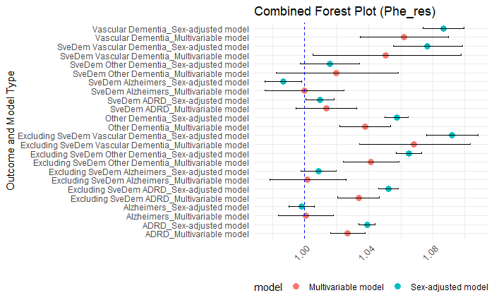

```r
library(ggplot2)
library(dplyr)
library(stringr)

# Assuming the dataframe is named 'your_dataframe'
# Filter for "phenoage_res" and add a unique row identifier combining outcome and model
combined_plot_df <- combined_df_results %>%
  filter(BA == "phenoage_res") %>%
  mutate(unique_id = paste(outcome, model, sep = "_"))

# Creating the combined forest plot
combined_forest_plot <- ggplot(combined_plot_df, aes(y = HR, x = as.factor(unique_id))) +
  geom_point(aes(color = model), size = 3) +
  geom_errorbar(aes(ymin = lb, ymax = ub), width = 0.2, size = 0.7) +
  geom_hline(yintercept = 1, linetype = "dashed", color = "blue", size = 0.7) +
  theme_minimal() +
  labs(title = "Combined Forest Plot (Phe_res)", y = "Hazard Ratio (HR)", x = "Outcome and Model Type") +
  coord_flip() +
  theme(legend.position = "bottom",
        axis.text.x = element_text(angle = 45, hjust = 1, size = 10),
        axis.title.x = element_blank())

# Display the combined plot
combined_forest_plot
```

Looking at it separatley:

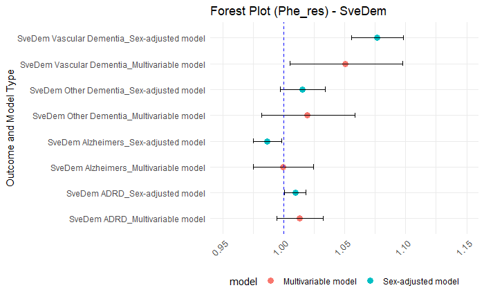

```r
library(ggplot2)
library(dplyr)
library(stringr)

# Assuming your dataframe is named 'combined_df_results'
# Filter for "phenoage_res" and add a unique row identifier combining outcome and model
combined_plot_df <- combined_df_results %>%
  filter(BA == "phenoage_res") %>%
  mutate(unique_id = paste(outcome, model, sep = "_"))

# Function to create a forest plot
create_forest_plot <- function(data, title_suffix) {
  ggplot(data, aes(y = HR, x = as.factor(unique_id))) +
    geom_point(aes(color = model), size = 3) +
    geom_errorbar(aes(ymin = lb, ymax = ub), width = 0.2, size = 0.7) +
    geom_hline(yintercept = 1, linetype = "dashed", color = "blue", size = 0.7) +
    theme_minimal() +
    labs(title = paste("Forest Plot (Phe_res) -", title_suffix), y = "Hazard Ratio (HR)", x = "Outcome and Model Type") +
    coord_flip() +
    scale_y_continuous(limits = c(0.95, 1.15)) +
    theme(legend.position = "bottom",
          axis.text.x = element_text(angle = 45, hjust = 1, size = 10),
          axis.title.x = element_blank())
}

# Outcomes starting with 'S'
outcomes_start_with_S <- combined_plot_df %>%
  filter(str_starts(outcome, "S"))

forest_plot_S <- create_forest_plot(outcomes_start_with_S, "SveDem")
forest_plot_S
```

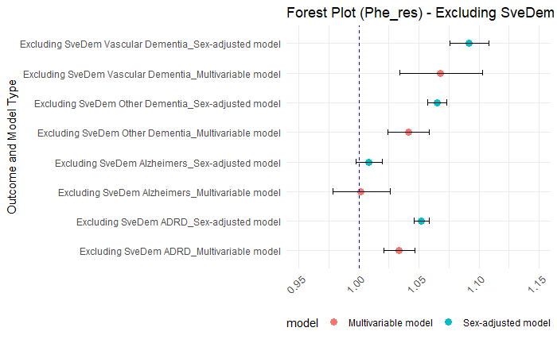

```r
# Outcomes starting with 'E'
outcomes_start_with_E <- combined_plot_df %>%
  filter(str_starts(outcome, "E"))

forest_plot_E <- create_forest_plot(outcomes_start_with_E, "Excluding SveDem")
forest_plot_E
```

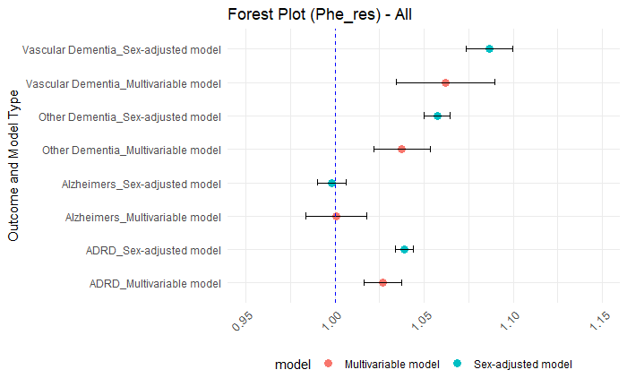

```r
# Outcomes not starting with 'S' or 'E'
outcomes_not_start_with_SE <- combined_plot_df %>%
  filter(!str_starts(outcome, "S") & !str_starts(outcome, "E"))

forest_plot_Others <- create_forest_plot(outcomes_not_start_with_SE, "All")
forest_plot_Others
```

```r
NA
NA
```

#========================================== #======== Subgroup analysis =============== #==========================================

## Under 65 vs over 65

ADRD

```r
BA_measures <- c("kdm_res", "phenoage_res", "hd_log_res")

# Initialize HR_BA_adrd data frame
HR_BA <- data.frame(
  BA = rep(BA_measures, each = 2),
  AgeGroup = rep(c("Under 65", "65 and over"), times = length(BA_measures)),
  model = rep("ADRD_agegroup", times = 2 * length(BA_measures)),
  beta = NA, se = NA, HR = NA,
  CI_lower = NA, CI_upper = NA, P_PH_BA = NA, global_p_PH_BA = NA, concordance = NA, N = NA
)

for (j in 1:length(BA_measures)) {
  # Loop over each BA measure
  for (age_group in c("Under 65", "65 and over")) {
    # Subset data based on age group
    if (age_group == "Under 65") {
      data_subset <- to1po2[to1po2$AgeAtLastDate < 65, ]
    } else {
      data_subset <- to1po2[to1po2$AgeAtLastDate >= 65, ]
    }

    # Fit Sex-adjusted model
    fit_gender <- coxph(as.formula(paste("Surv(AgeAtFirstDate, AgeAtLastDate, ADRD) ~", BA_measures[j], "+ gender")), data = data_subset)
    coef_gender <- summary(fit_gender)

    # Determine row index for updating HR_BA
    if (age_group == "Under 65") {
      row_index <- (j - 1) * 2 + 1
    } else {
      row_index <- j * 2
    }

    # Update HR_BA with model results
    HR_BA[row_index, c("beta", "se", "HR")] <- coef_gender$coefficients[1, c(1, 3, 2)]
    HR_BA[row_index, c("CI_lower", "CI_upper")] <- coef_gender$conf.int[1, c(3, 4)]
    HR_BA[row_index, "P_PH_BA"] <- cox.zph(fit_gender)$table[1, 3]
    HR_BA[row_index, "global_p_PH_BA"] <- cox.zph(fit_gender)$table[3, 3]
    HR_BA[row_index, "concordance"] <- coef_gender$concordance[1]
    HR_BA[row_index, "N"] <- coef_gender$n
  }
}
ADRD_agegroup <- HR_BA
# Print the updated HR_BA data frame
print(HR_BA)
```

| BA | AgeGroup | model | beta | se | HR | CI_lower | CI_upper | P_PH_BA | global_p_PH_BA | concordance | N |
| --- | --- | --- | --- | --- | --- | --- | --- | --- | --- | --- | --- |
| kdm_res | Under 65 | ADRD_agegroup | 0.008254278 | 0.006305935 | 1.008288 | 0.9959033 | 1.020828 | 1.608975e-01 | 3.278298e-01 | 0.5509532 | 56195 |
| kdm_res | 65 and over | ADRD_agegroup | 0.013599299 | 0.001670242 | 1.013692 | 1.0103792 | 1.017016 | 4.258505e-01 | 6.645846e-01 | 0.5103855 | 175547 |
| phenoage_res | Under 65 | ADRD_agegroup | 0.038814492 | 0.008150774 | 1.039578 | 1.0231021 | 1.056318 | 7.829978e-01 | 9.541582e-01 | 0.5462356 | 77505 |
| phenoage_res | 65 and over | ADRD_agegroup | 0.035468631 | 0.002587428 | 1.036105 | 1.0308641 | 1.041373 | 6.665226e-11 | 8.915993e-11 | 0.5352061 | 182305 |
| hd_log_res | Under 65 | ADRD_agegroup | 0.120979814 | 0.024708814 | 1.128602 | 1.0752481 | 1.184604 | 9.318160e-01 | 9.854832e-01 | 0.5408309 | 77505 |
| hd_log_res | 65 and over | ADRD_agegroup | 0.106491318 | 0.008085323 | 1.112368 | 1.0948796 | 1.130136 | 1.234702e-08 | 2.506821e-08 | 0.5335349 | 182305 |

```r
NA
```

SveDem ADRD

```r
BA_measures <- c("kdm_res", "phenoage_res", "hd_log_res")

# Initialize HR_BA data frame
HR_BA <- data.frame(
  BA = rep(BA_measures, each = 2),
  AgeGroup = rep(c("Under 65", "65 and over"), times = length(BA_measures)),
  model = rep("S_ADRD_agegroup", times = 2 * length(BA_measures)),
  beta = NA, se = NA, HR = NA,
  CI_lower = NA, CI_upper = NA, P_PH_BA = NA, global_p_PH_BA = NA, concordance = NA, N = NA
)

for (j in 1:length(BA_measures)) {
  # Loop over each BA measure
  for (age_group in c("Under 65", "65 and over")) {
    # Subset data based on age group
    if (age_group == "Under 65") {
      data_subset <- to1po2[to1po2$AgeAtLastDate < 65, ]
    } else {
      data_subset <- to1po2[to1po2$AgeAtLastDate >= 65, ]
    }

    # Fit Sex-adjusted model
    fit_gender <- coxph(as.formula(paste("Surv(AgeAtFirstDate, AgeAtLastDate, S_ADRD) ~", BA_measures[j], "+ gender")), data = data_subset)
    coef_gender <- summary(fit_gender)

    # Determine row index for updating HR_BA
    if (age_group == "Under 65") {
      row_index <- (j - 1) * 2 + 1
    } else {
      row_index <- j * 2
    }

    # Update HR_BA with model results
    HR_BA[row_index, c("beta", "se", "HR")] <- coef_gender$coefficients[1, c(1, 3, 2)]
    HR_BA[row_index, c("CI_lower", "CI_upper")] <- coef_gender$conf.int[1, c(3, 4)]
    HR_BA[row_index, "P_PH_BA"] <- cox.zph(fit_gender)$table[1, 3]
    HR_BA[row_index, "global_p_PH_BA"] <- cox.zph(fit_gender)$table[3, 3]
    HR_BA[row_index, "concordance"] <- coef_gender$concordance[1]
    HR_BA[row_index, "N"] <- coef_gender$n
  }
}

S_ADRD_agegroup <- HR_BA

# Print the updated HR_BA data frame
print(HR_BA)
```

| BA | AgeGroup | model | beta | se | HR | CI_lower | CI_upper | P_PH_BA | global_p_PH_BA | concordance | N |
| --- | --- | --- | --- | --- | --- | --- | --- | --- | --- | --- | --- |
| kdm_res | Under 65 | S_ADRD_agegroup | 0.003479615 | 0.016932213 | 1.003486 | 0.9707300 | 1.037347 | 2.539070e-02 | 1.091415e-02 | 0.5109792 | 56195 |
| kdm_res | 65 and over | S_ADRD_agegroup | 0.013273899 | 0.002812727 | 1.013362 | 1.0077913 | 1.018964 | 2.786265e-01 | 3.845937e-01 | 0.5159490 | 175547 |
| phenoage_res | Under 65 | S_ADRD_agegroup | 0.015102008 | 0.021953999 | 1.015217 | 0.9724593 | 1.059854 | 2.445984e-01 | 1.052514e-02 | 0.4840500 | 77505 |
| phenoage_res | 65 and over | S_ADRD_agegroup | 0.007537540 | 0.004604904 | 1.007566 | 0.9985132 | 1.016701 | 1.045996e-05 | 2.018218e-07 | 0.5141922 | 182305 |
| hd_log_res | Under 65 | S_ADRD_agegroup | 0.049775672 | 0.066578631 | 1.051035 | 0.9224556 | 1.197538 | 4.725130e-01 | 2.931144e-02 | 0.4902087 | 77505 |
| hd_log_res | 65 and over | S_ADRD_agegroup | 0.082425430 | 0.014115200 | 1.085918 | 1.0562872 | 1.116379 | 4.913506e-03 | 8.009148e-05 | 0.5274664 | 182305 |

```r
NA
```

Excluding SveDem ADRD

```r
BA_measures <- c("kdm_res", "phenoage_res", "hd_log_res")

# Initialize HR_BA data frame
HR_BA <- data.frame(
  BA = rep(BA_measures, each = 2),
  AgeGroup = rep(c("Under 65", "65 and over"), times = length(BA_measures)),
  model = rep("NS_ADRD_agegroup", times = 2 * length(BA_measures)),
  beta = NA, se = NA, HR = NA,
  CI_lower = NA, CI_upper = NA, P_PH_BA = NA, global_p_PH_BA = NA, concordance = NA, N = NA
)

for (j in 1:length(BA_measures)) {
  # Loop over each BA measure
  for (age_group in c("Under 65", "65 and over")) {
    # Subset data based on age group
    if (age_group == "Under 65") {
      data_subset <- to1po2[to1po2$AgeAtLastDate < 65, ]
    } else {
      data_subset <- to1po2[to1po2$AgeAtLastDate >= 65, ]
    }

    # Fit Sex-adjusted model
    fit_gender <- coxph(as.formula(paste("Surv(AgeAtFirstDate, AgeAtLastDate, NS_ADRD) ~", BA_measures[j], "+ gender")), data = data_subset)
    coef_gender <- summary(fit_gender)

    # Determine row index for updating HR_BA
    if (age_group == "Under 65") {
      row_index <- (j - 1) * 2 + 1
    } else {
      row_index <- j * 2
    }

    # Update HR_BA with model results
    HR_BA[row_index, c("beta", "se", "HR")] <- coef_gender$coefficients[1, c(1, 3, 2)]
    HR_BA[row_index, c("CI_lower", "CI_upper")] <- coef_gender$conf.int[1, c(3, 4)]
    HR_BA[row_index, "P_PH_BA"] <- cox.zph(fit_gender)$table[1, 3]
    HR_BA[row_index, "global_p_PH_BA"] <- cox.zph(fit_gender)$table[3, 3]
    HR_BA[row_index, "concordance"] <- coef_gender$concordance[1]
    HR_BA[row_index, "N"] <- coef_gender$n
  }
}

NS_ADRD_agegroup <- HR_BA

# Print the updated HR_BA data frame
print(HR_BA)
```

| BA | AgeGroup | model | beta | se | HR | CI_lower | CI_upper | P_PH_BA | global_p_PH_BA | concordance | N |
| --- | --- | --- | --- | --- | --- | --- | --- | --- | --- | --- | --- |
| kdm_res | Under 65 | NS_ADRD_agegroup | 0.009021435 | 0.006795546 | 1.009062 | 0.9957116 | 1.022592 | 6.036500e-01 | 3.085949e-01 | 0.5560527 | 56195 |
| kdm_res | 65 and over | NS_ADRD_agegroup | 0.013758348 | 0.002076849 | 1.013853 | 1.0097349 | 1.017989 | 9.377123e-01 | 4.656966e-01 | 0.5076331 | 175547 |
| phenoage_res | Under 65 | NS_ADRD_agegroup | 0.042682756 | 0.008778496 | 1.043607 | 1.0258045 | 1.061718 | 5.057965e-01 | 4.795563e-01 | 0.5531788 | 77505 |
| phenoage_res | 65 and over | NS_ADRD_agegroup | 0.048782691 | 0.003127409 | 1.049992 | 1.0435758 | 1.056448 | 6.054395e-08 | 4.037725e-07 | 0.5453703 | 182305 |
| hd_log_res | Under 65 | NS_ADRD_agegroup | 0.132419656 | 0.026609855 | 1.141587 | 1.0835745 | 1.202706 | 7.329277e-01 | 6.142613e-01 | 0.5464206 | 77505 |
| hd_log_res | 65 and over | NS_ADRD_agegroup | 0.118406797 | 0.009866857 | 1.125702 | 1.1041415 | 1.147683 | 5.725274e-07 | 3.710392e-06 | 0.5360560 | 182305 |

Alzheimers

```r
BA_measures <- c("kdm_res", "phenoage_res", "hd_log_res")

# Initialize HR_BA data frame
HR_BA <- data.frame(
  BA = rep(BA_measures, each = 2),
  AgeGroup = rep(c("Under 65", "65 and over"), times = length(BA_measures)),
  model = rep("Alzheimers_agegroup", times = 2 * length(BA_measures)),
  beta = NA, se = NA, HR = NA,
  CI_lower = NA, CI_upper = NA, P_PH_BA = NA, global_p_PH_BA = NA, concordance = NA, N = NA
)

for (j in 1:length(BA_measures)) {
  # Loop over each BA measure
  for (age_group in c("Under 65", "65 and over")) {
    # Subset data based on age group
    if (age_group == "Under 65") {
      data_subset <- to1po2[to1po2$AgeAtLastDate < 65, ]
    } else {
      data_subset <- to1po2[to1po2$AgeAtLastDate >= 65, ]
    }

    # Fit Sex-adjusted model
    fit_gender <- coxph(as.formula(paste("Surv(AgeAtFirstDate, AgeAtLastDate, Alzheimers) ~", BA_measures[j], "+ gender")), data = data_subset)
    coef_gender <- summary(fit_gender)

    # Determine row index for updating HR_BA
    if (age_group == "Under 65") {
      row_index <- (j - 1) * 2 + 1
    } else {
      row_index <- j * 2
    }

    # Update HR_BA with model results
    HR_BA[row_index, c("beta", "se", "HR")] <- coef_gender$coefficients[1, c(1, 3, 2)]
    HR_BA[row_index, c("CI_lower", "CI_upper")] <- coef_gender$conf.int[1, c(3, 4)]
    HR_BA[row_index, "P_PH_BA"] <- cox.zph(fit_gender)$table[1, 3]
    HR_BA[row_index, "global_p_PH_BA"] <- cox.zph(fit_gender)$table[3, 3]
    HR_BA[row_index, "concordance"] <- coef_gender$concordance[1]
    HR_BA[row_index, "N"] <- coef_gender$n
  }
}
Alzheimers_agegroup <- HR_BA

# Print the updated HR_BA data frame
print(HR_BA)
```

| BA | AgeGroup | model | beta | se | HR | CI_lower | CI_upper | P_PH_BA | global_p_PH_BA | concordance | N |
| --- | --- | --- | --- | --- | --- | --- | --- | --- | --- | --- | --- |
| kdm_res | Under 65 | Alzheimers_agegroup | 0.002027189 | 0.013849960 | 1.0020292 | 0.9751946 | 1.029602 | 0.2700947 | 1.433403e-01 | 0.5416757 | 56195 |
| kdm_res | 65 and over | Alzheimers_agegroup | 0.010000770 | 0.002530372 | 1.0100509 | 1.0050541 | 1.015073 | 0.1415215 | 8.256672e-04 | 0.5357810 | 175547 |
| phenoage_res | Under 65 | Alzheimers_agegroup | -0.029030628 | 0.018934853 | 0.9713867 | 0.9359977 | 1.008114 | 0.1036894 | 1.576137e-02 | 0.5156404 | 77505 |
| phenoage_res | 65 and over | Alzheimers_agegroup | -0.002762468 | 0.004176345 | 0.9972413 | 0.9891118 | 1.005438 | 0.0366881 | 3.074208e-06 | 0.5290413 | 182305 |
| hd_log_res | Under 65 | Alzheimers_agegroup | -0.051657347 | 0.055766518 | 0.9496542 | 0.8513281 | 1.059337 | 0.1172128 | 2.685453e-02 | 0.5205227 | 77505 |
| hd_log_res | 65 and over | Alzheimers_agegroup | 0.039759538 | 0.012739535 | 1.0405605 | 1.0149004 | 1.066869 | 0.1185147 | 5.474832e-06 | 0.5367338 | 182305 |

SveDem Alzheimers

```r
BA_measures <- c("kdm_res", "phenoage_res", "hd_log_res")

# Initialize HR_BA data frame
HR_BA <- data.frame(
  BA = rep(BA_measures, each = 2),
  AgeGroup = rep(c("Under 65", "65 and over"), times = length(BA_measures)),
  model = rep("S_Alzheimers_agegroup", times = 2 * length(BA_measures)),
  beta = NA, se = NA, HR = NA,
  CI_lower = NA, CI_upper = NA, P_PH_BA = NA, global_p_PH_BA = NA, concordance = NA, N = NA
)

for (j in 1:length(BA_measures)) {
  # Loop over each BA measure
  for (age_group in c("Under 65", "65 and over")) {
    # Subset data based on age group
    if (age_group == "Under 65") {
      data_subset <- to1po2[to1po2$AgeAtLastDate < 65, ]
    } else {
      data_subset <- to1po2[to1po2$AgeAtLastDate >= 65, ]
    }

    # Fit Sex-adjusted model
    fit_gender <- coxph(as.formula(paste("Surv(AgeAtFirstDate, AgeAtLastDate, S_Alzheimers) ~", BA_measures[j], "+ gender")), data = data_subset)
    coef_gender <- summary(fit_gender)

    # Determine row index for updating HR_BA
    if (age_group == "Under 65") {
      row_index <- (j - 1) * 2 + 1
    } else {
      row_index <- j * 2
    }

    # Update HR_BA with model results
    HR_BA[row_index, c("beta", "se", "HR")] <- coef_gender$coefficients[1, c(1, 3, 2)]
    HR_BA[row_index, c("CI_lower", "CI_upper")] <- coef_gender$conf.int[1, c(3, 4)]
    HR_BA[row_index, "P_PH_BA"] <- cox.zph(fit_gender)$table[1, 3]
    HR_BA[row_index, "global_p_PH_BA"] <- cox.zph(fit_gender)$table[3, 3]
    HR_BA[row_index, "concordance"] <- coef_gender$concordance[1]
    HR_BA[row_index, "N"] <- coef_gender$n
  }
}

S_Alzheimers_agegroup <- HR_BA

# Print the updated HR_BA data frame
print(HR_BA)
```

| BA | AgeGroup | model | beta | se | HR | CI_lower | CI_upper | P_PH_BA | global_p_PH_BA | concordance | N |
| --- | --- | --- | --- | --- | --- | --- | --- | --- | --- | --- | --- |
| kdm_res | Under 65 | S_Alzheimers_agegroup | 0.005285288 | 0.024341932 | 1.0052993 | 0.9584633 | 1.0544239 | 0.07433364 | 6.141263e-02 | 0.5027198 | 56195 |
| kdm_res | 65 and over | S_Alzheimers_agegroup | 0.011577944 | 0.003543974 | 1.0116452 | 1.0046426 | 1.0186966 | 0.14469309 | 1.228424e-03 | 0.5401313 | 175547 |
| phenoage_res | Under 65 | S_Alzheimers_agegroup | -0.042759764 | 0.033260141 | 0.9581415 | 0.8976739 | 1.0226823 | 0.39512746 | 6.450763e-02 | 0.5224412 | 77505 |
| phenoage_res | 65 and over | S_Alzheimers_agegroup | -0.013921775 | 0.006054709 | 0.9861747 | 0.9745409 | 0.9979473 | 0.01804330 | 1.809677e-07 | 0.5315496 | 182305 |
| hd_log_res | Under 65 | S_Alzheimers_agegroup | -0.162775573 | 0.097806461 | 0.8497819 | 0.7015433 | 1.0293439 | 0.34236076 | 7.193383e-02 | 0.5376377 | 77505 |
| hd_log_res | 65 and over | S_Alzheimers_agegroup | 0.038997265 | 0.018319829 | 1.0397676 | 1.0030958 | 1.0777801 | 0.28135029 | 1.373065e-06 | 0.5378837 | 182305 |

Excluding SveDem Alzheimers

```r
BA_measures <- c("kdm_res", "phenoage_res", "hd_log_res")

# Initialize HR_BA data frame
HR_BA <- data.frame(
  BA = rep(BA_measures, each = 2),
  AgeGroup = rep(c("Under 65", "65 and over"), times = length(BA_measures)),
  model = rep("NS_Alzheimers_agegroup", times = 2 * length(BA_measures)),
  beta = NA, se = NA, HR = NA,
  CI_lower = NA, CI_upper = NA, P_PH_BA = NA, global_p_PH_BA = NA, concordance = NA, N = NA
)

for (j in 1:length(BA_measures)) {
  # Loop over each BA measure
  for (age_group in c("Under 65", "65 and over")) {
    # Subset data based on age group
    if (age_group == "Under 65") {
      data_subset <- to1po2[to1po2$AgeAtLastDate < 65, ]
    } else {
      data_subset <- to1po2[to1po2$AgeAtLastDate >= 65, ]
    }

    # Fit Sex-adjusted model
    fit_gender <- coxph(as.formula(paste("Surv(AgeAtFirstDate, AgeAtLastDate, NS_Alzheimers) ~", BA_measures[j], "+ gender")), data = data_subset)
    coef_gender <- summary(fit_gender)

    # Determine row index for updating HR_BA
    if (age_group == "Under 65") {
      row_index <- (j - 1) * 2 + 1
    } else {
      row_index <- j * 2
    }

    # Update HR_BA with model results
    HR_BA[row_index, c("beta", "se", "HR")] <- coef_gender$coefficients[1, c(1, 3, 2)]
    HR_BA[row_index, c("CI_lower", "CI_upper")] <- coef_gender$conf.int[1, c(3, 4)]
    HR_BA[row_index, "P_PH_BA"] <- cox.zph(fit_gender)$table[1, 3]
    HR_BA[row_index, "global_p_PH_BA"] <- cox.zph(fit_gender)$table[3, 3]
    HR_BA[row_index, "concordance"] <- coef_gender$concordance[1]
    HR_BA[row_index, "N"] <- coef_gender$n
  }
}

NS_Alzheimers_agegroup <- HR_BA

# Print the updated HR_BA data frame
print(HR_BA)
```

| BA | AgeGroup | model | beta | se | HR | CI_lower | CI_upper | P_PH_BA | global_p_PH_BA | concordance | N |
| --- | --- | --- | --- | --- | --- | --- | --- | --- | --- | --- | --- |
| kdm_res | Under 65 | NS_Alzheimers_agegroup | 0.0004797751 | 0.016841201 | 1.0004799 | 0.9679950 | 1.034055 | 0.9583584 | 0.7536650 | 0.5609782 | 56195 |
| kdm_res | 65 and over | NS_Alzheimers_agegroup | 0.0083623953 | 0.003614349 | 1.0083975 | 1.0012792 | 1.015566 | 0.4039995 | 0.3411652 | 0.5320598 | 175547 |
| phenoage_res | Under 65 | NS_Alzheimers_agegroup | -0.0223067909 | 0.023027441 | 0.9779402 | 0.9347840 | 1.023089 | 0.1650626 | 0.1846946 | 0.5275064 | 77505 |
| phenoage_res | 65 and over | NS_Alzheimers_agegroup | 0.0075885927 | 0.005766790 | 1.0076175 | 0.9962928 | 1.019071 | 0.6026405 | 0.4043551 | 0.5342099 | 182305 |
| hd_log_res | Under 65 | NS_Alzheimers_agegroup | 0.0027717834 | 0.067805387 | 1.0027756 | 0.8779863 | 1.145301 | 0.2202194 | 0.2760061 | 0.5159729 | 77505 |
| hd_log_res | 65 and over | NS_Alzheimers_agegroup | 0.0406325539 | 0.017727921 | 1.0414694 | 1.0059038 | 1.078292 | 0.2331663 | 0.2012486 | 0.5354664 | 182305 |

Vascular

```r
BA_measures <- c("kdm_res", "phenoage_res", "hd_log_res")

# Initialize HR_BA data frame
HR_BA <- data.frame(
  BA = rep(BA_measures, each = 2),
  AgeGroup = rep(c("Under 65", "65 and over"), times = length(BA_measures)),
  model = rep("Vascular_agegroup", times = 2 * length(BA_measures)),
  beta = NA, se = NA, HR = NA,
  CI_lower = NA, CI_upper = NA, P_PH_BA = NA, global_p_PH_BA = NA, concordance = NA, N = NA
)

for (j in 1:length(BA_measures)) {
  # Loop over each BA measure
  for (age_group in c("Under 65", "65 and over")) {
    # Subset data based on age group
    if (age_group == "Under 65") {
      data_subset <- to1po2[to1po2$AgeAtLastDate < 65, ]
    } else {
      data_subset <- to1po2[to1po2$AgeAtLastDate >= 65, ]
    }

    # Fit Sex-adjusted model
    fit_gender <- coxph(as.formula(paste("Surv(AgeAtFirstDate, AgeAtLastDate, Vascular) ~", BA_measures[j], "+ gender")), data = data_subset)
    coef_gender <- summary(fit_gender)

    # Determine row index for updating HR_BA
    if (age_group == "Under 65") {
      row_index <- (j - 1) * 2 + 1
    } else {
      row_index <- j * 2
    }

    # Update HR_BA with model results
    HR_BA[row_index, c("beta", "se", "HR")] <- coef_gender$coefficients[1, c(1, 3, 2)]
    HR_BA[row_index, c("CI_lower", "CI_upper")] <- coef_gender$conf.int[1, c(3, 4)]
    HR_BA[row_index, "P_PH_BA"] <- cox.zph(fit_gender)$table[1, 3]
    HR_BA[row_index, "global_p_PH_BA"] <- cox.zph(fit_gender)$table[3, 3]
    HR_BA[row_index, "concordance"] <- coef_gender$concordance[1]
    HR_BA[row_index, "N"] <- coef_gender$n
  }
}

Vascular_agegroup <- HR_BA
# Print the updated HR_BA data frame
print(HR_BA)
```

| BA | AgeGroup | model | beta | se | HR | CI_lower | CI_upper | P_PH_BA | global_p_PH_BA | concordance | N |
| --- | --- | --- | --- | --- | --- | --- | --- | --- | --- | --- | --- |
| kdm_res | Under 65 | Vascular_agegroup | 0.02849208 | 0.028430253 | 1.028902 | 0.9731372 | 1.087862 | 2.545176e-01 | 4.638184e-01 | 0.5530242 | 56195 |
| kdm_res | 65 and over | Vascular_agegroup | 0.01530858 | 0.004341972 | 1.015426 | 1.0068216 | 1.024105 | 2.716050e-01 | 3.708773e-05 | 0.5310782 | 175547 |
| phenoage_res | Under 65 | Vascular_agegroup | 0.14627452 | 0.027238546 | 1.157514 | 1.0973388 | 1.220989 | 6.102613e-01 | 8.521918e-01 | 0.6502940 | 77505 |
| phenoage_res | 65 and over | Vascular_agegroup | 0.07805160 | 0.006224117 | 1.081178 | 1.0680692 | 1.094449 | 7.477641e-09 | 3.648984e-09 | 0.5876356 | 182305 |
| hd_log_res | Under 65 | Vascular_agegroup | 0.37745340 | 0.091290286 | 1.458565 | 1.2196058 | 1.744345 | 2.954339e-01 | 5.783840e-01 | 0.6227595 | 77505 |
| hd_log_res | 65 and over | Vascular_agegroup | 0.21485791 | 0.019957658 | 1.239686 | 1.1921300 | 1.289139 | 1.527658e-05 | 2.283855e-06 | 0.5786461 | 182305 |

SveDem Vascular

```r
BA_measures <- c("kdm_res", "phenoage_res", "hd_log_res")

# Initialize HR_BA data frame
HR_BA <- data.frame(
  BA = rep(BA_measures, each = 2),
  AgeGroup = rep(c("Under 65", "65 and over"), times = length(BA_measures)),
  model = rep("S_Vascular_agegroup", times = 2 * length(BA_measures)),
  beta = NA, se = NA, HR = NA,
  CI_lower = NA, CI_upper = NA, P_PH_BA = NA, global_p_PH_BA = NA, concordance = NA, N = NA
)

for (j in 1:length(BA_measures)) {
  # Loop over each BA measure
  for (age_group in c("Under 65", "65 and over")) {
    # Subset data based on age group
    if (age_group == "Under 65") {
      data_subset <- to1po2[to1po2$AgeAtLastDate < 65, ]
    } else {
      data_subset <- to1po2[to1po2$AgeAtLastDate >= 65, ]
    }

    # Fit Sex-adjusted model
    fit_gender <- coxph(as.formula(paste("Surv(AgeAtFirstDate, AgeAtLastDate, S_Vascular) ~", BA_measures[j], "+ gender")), data = data_subset)
    coef_gender <- summary(fit_gender)

    # Determine row index for updating HR_BA
    if (age_group == "Under 65") {
      row_index <- (j - 1) * 2 + 1
    } else {
      row_index <- j * 2
    }

    # Update HR_BA with model results
    HR_BA[row_index, c("beta", "se", "HR")] <- coef_gender$coefficients[1, c(1, 3, 2)]
    HR_BA[row_index, c("CI_lower", "CI_upper")] <- coef_gender$conf.int[1, c(3, 4)]
    HR_BA[row_index, "P_PH_BA"] <- cox.zph(fit_gender)$table[1, 3]
    HR_BA[row_index, "global_p_PH_BA"] <- cox.zph(fit_gender)$table[3, 3]
    HR_BA[row_index, "concordance"] <- coef_gender$concordance[1]
    HR_BA[row_index, "N"] <- coef_gender$n
  }
}

S_Vascular_agegroup <- HR_BA
# Print the updated HR_BA data frame
print(HR_BA)
```

| BA | AgeGroup | model | beta | se | HR | CI_lower | CI_upper | P_PH_BA | global_p_PH_BA | concordance | N |
| --- | --- | --- | --- | --- | --- | --- | --- | --- | --- | --- | --- |
| kdm_res | Under 65 | S_Vascular_agegroup | 0.04675956 | 0.050704323 | 1.047870 | 0.9487413 | 1.157356 | 0.781020179 | 0.92346592 | 0.5399860 | 56195 |
| kdm_res | 65 and over | S_Vascular_agegroup | 0.01083673 | 0.007100941 | 1.010896 | 0.9969239 | 1.025063 | 0.918405213 | 0.37220350 | 0.5241578 | 175547 |
| phenoage_res | Under 65 | S_Vascular_agegroup | 0.15914630 | 0.050925043 | 1.172509 | 1.0611307 | 1.295579 | 0.047294026 | 0.13414366 | 0.5497588 | 77505 |
| phenoage_res | 65 and over | S_Vascular_agegroup | 0.06937432 | 0.010408021 | 1.071837 | 1.0501941 | 1.093927 | 0.002576922 | 0.01063347 | 0.5794868 | 182305 |
| hd_log_res | Under 65 | S_Vascular_agegroup | 0.42754592 | 0.171710606 | 1.533490 | 1.0952683 | 2.147045 | 0.151513737 | 0.35742005 | 0.5929317 | 77505 |
| hd_log_res | 65 and over | S_Vascular_agegroup | 0.20145147 | 0.033175190 | 1.223177 | 1.1461738 | 1.305353 | 0.010979912 | 0.03858878 | 0.5738611 | 182305 |

Excluding SveDem Vascular

```r
BA_measures <- c("kdm_res", "phenoage_res", "hd_log_res")

# Initialize HR_BA data frame
HR_BA <- data.frame(
  BA = rep(BA_measures, each = 2),
  AgeGroup = rep(c("Under 65", "65 and over"), times = length(BA_measures)),
  model = rep("NS_Vascular_agegroup", times = 2 * length(BA_measures)),
  beta = NA, se = NA, HR = NA,
  CI_lower = NA, CI_upper = NA, P_PH_BA = NA, global_p_PH_BA = NA, concordance = NA, N = NA
)

for (j in 1:length(BA_measures)) {
  # Loop over each BA measure
  for (age_group in c("Under 65", "65 and over")) {
    # Subset data based on age group
    if (age_group == "Under 65") {
      data_subset <- to1po2[to1po2$AgeAtLastDate < 65, ]
    } else {
      data_subset <- to1po2[to1po2$AgeAtLastDate >= 65, ]
    }

    # Fit Sex-adjusted model
    fit_gender <- coxph(as.formula(paste("Surv(AgeAtFirstDate, AgeAtLastDate, NS_Vascular) ~", BA_measures[j], "+ gender")), data = data_subset)
    coef_gender <- summary(fit_gender)

    # Determine row index for updating HR_BA
    if (age_group == "Under 65") {
      row_index <- (j - 1) * 2 + 1
    } else {
      row_index <- j * 2
    }

    # Update HR_BA with model results
    HR_BA[row_index, c("beta", "se", "HR")] <- coef_gender$coefficients[1, c(1, 3, 2)]
    HR_BA[row_index, c("CI_lower", "CI_upper")] <- coef_gender$conf.int[1, c(3, 4)]
    HR_BA[row_index, "P_PH_BA"] <- cox.zph(fit_gender)$table[1, 3]
    HR_BA[row_index, "global_p_PH_BA"] <- cox.zph(fit_gender)$table[3, 3]
    HR_BA[row_index, "concordance"] <- coef_gender$concordance[1]
    HR_BA[row_index, "N"] <- coef_gender$n
  }
}

NS_Vascular_agegroup <- HR_BA
# Print the updated HR_BA data frame
print(HR_BA)
```

| BA | AgeGroup | model | beta | se | HR | CI_lower | CI_upper | P_PH_BA | global_p_PH_BA | concordance | N |
| --- | --- | --- | --- | --- | --- | --- | --- | --- | --- | --- | --- |
| kdm_res | Under 65 | NS_Vascular_agegroup | 0.02047191 | 0.034307746 | 1.020683 | 0.9543068 | 1.091676 | 8.547909e-02 | 2.216206e-01 | 0.5570575 | 56195 |
| kdm_res | 65 and over | NS_Vascular_agegroup | 0.01800154 | 0.005486792 | 1.018165 | 1.0072740 | 1.029173 | 1.469212e-01 | 1.887126e-05 | 0.5343062 | 175547 |
| phenoage_res | Under 65 | NS_Vascular_agegroup | 0.14121415 | 0.032230073 | 1.151671 | 1.0811706 | 1.226769 | 2.543254e-02 | 7.467721e-02 | 0.6877966 | 77505 |
| phenoage_res | 65 and over | NS_Vascular_agegroup | 0.08294491 | 0.007765069 | 1.086482 | 1.0700717 | 1.103144 | 4.752119e-07 | 6.039062e-08 | 0.5920851 | 182305 |
| hd_log_res | Under 65 | NS_Vascular_agegroup | 0.35796904 | 0.107771802 | 1.430421 | 1.1580530 | 1.766849 | 9.620038e-01 | 9.965375e-01 | 0.6357863 | 77505 |
| hd_log_res | 65 and over | NS_Vascular_agegroup | 0.22250193 | 0.024983924 | 1.249198 | 1.1895015 | 1.311891 | 3.957867e-04 | 1.351687e-05 | 0.5808603 | 182305 |

Other Dementia

```r
BA_measures <- c("kdm_res", "phenoage_res", "hd_log_res")

# Initialize HR_BA data frame
HR_BA <- data.frame(
  BA = rep(BA_measures, each = 2),
  AgeGroup = rep(c("Under 65", "65 and over"), times = length(BA_measures)),
  model = rep("Other_agegroup", times = 2 * length(BA_measures)),
  beta = NA, se = NA, HR = NA,
  CI_lower = NA, CI_upper = NA, P_PH_BA = NA, global_p_PH_BA = NA, concordance = NA, N = NA
)

for (j in 1:length(BA_measures)) {
  # Loop over each BA measure
  for (age_group in c("Under 65", "65 and over")) {
    # Subset data based on age group
    if (age_group == "Under 65") {
      data_subset <- to1po2[to1po2$AgeAtLastDate < 65, ]
    } else {
      data_subset <- to1po2[to1po2$AgeAtLastDate >= 65, ]
    }

    # Fit Sex-adjusted model
    fit_gender <- coxph(as.formula(paste("Surv(AgeAtFirstDate, AgeAtLastDate, Other) ~", BA_measures[j], "+ gender")), data = data_subset)
    coef_gender <- summary(fit_gender)

    # Determine row index for updating HR_BA
    if (age_group == "Under 65") {
      row_index <- (j - 1) * 2 + 1
    } else {
      row_index <- j * 2
    }

    # Update HR_BA with model results
    HR_BA[row_index, c("beta", "se", "HR")] <- coef_gender$coefficients[1, c(1, 3, 2)]
    HR_BA[row_index, c("CI_lower", "CI_upper")] <- coef_gender$conf.int[1, c(3, 4)]
    HR_BA[row_index, "P_PH_BA"] <- cox.zph(fit_gender)$table[1, 3]
    HR_BA[row_index, "global_p_PH_BA"] <- cox.zph(fit_gender)$table[3, 3]
    HR_BA[row_index, "concordance"] <- coef_gender$concordance[1]
    HR_BA[row_index, "N"] <- coef_gender$n
  }
}

Other_agegroup <- HR_BA

# Print the updated HR_BA data frame
print(HR_BA)
```

| BA | AgeGroup | model | beta | se | HR | CI_lower | CI_upper | P_PH_BA | global_p_PH_BA | concordance | N |
| --- | --- | --- | --- | --- | --- | --- | --- | --- | --- | --- | --- |
| kdm_res | Under 65 | Other_agegroup | 0.008601922 | 0.007320187 | 1.008639 | 0.9942711 | 1.023215 | 4.820507e-01 | 5.449280e-01 | 0.5589186 | 56195 |
| kdm_res | 65 and over | Other_agegroup | 0.016679936 | 0.002590989 | 1.016820 | 1.0116693 | 1.021997 | 5.557517e-01 | 1.018820e-01 | 0.5160663 | 175547 |
| phenoage_res | Under 65 | Other_agegroup | 0.045405666 | 0.009553943 | 1.046452 | 1.0270394 | 1.066232 | 5.239570e-01 | 7.709288e-01 | 0.5560357 | 77505 |
| phenoage_res | 65 and over | Other_agegroup | 0.054042463 | 0.003881415 | 1.055529 | 1.0475300 | 1.063590 | 1.045292e-07 | 6.266145e-07 | 0.5517955 | 182305 |
| hd_log_res | Under 65 | Other_agegroup | 0.143434992 | 0.028875280 | 1.154232 | 1.0907227 | 1.221439 | 2.927750e-01 | 5.317598e-01 | 0.5515849 | 77505 |
| hd_log_res | 65 and over | Other_agegroup | 0.128957914 | 0.012282201 | 1.137642 | 1.1105832 | 1.165361 | 2.568667e-06 | 1.064119e-05 | 0.5418882 | 182305 |

SveDem Other

```r
BA_measures <- c("kdm_res", "phenoage_res", "hd_log_res")

# Initialize HR_BA data frame
HR_BA <- data.frame(
  BA = rep(BA_measures, each = 2),
  AgeGroup = rep(c("Under 65", "65 and over"), times = length(BA_measures)),
  model = rep("S_Other_agegroup", times = 2 * length(BA_measures)),
  beta = NA, se = NA, HR = NA,
  CI_lower = NA, CI_upper = NA, P_PH_BA = NA, global_p_PH_BA = NA, concordance = NA, N = NA
)

for (j in 1:length(BA_measures)) {
  # Loop over each BA measure
  for (age_group in c("Under 65", "65 and over")) {
    # Subset data based on age group
    if (age_group == "Under 65") {
      data_subset <- to1po2[to1po2$AgeAtLastDate < 65, ]
    } else {
      data_subset <- to1po2[to1po2$AgeAtLastDate >= 65, ]
    }

    # Fit Sex-adjusted model
    fit_gender <- coxph(as.formula(paste("Surv(AgeAtFirstDate, AgeAtLastDate, S_other) ~", BA_measures[j], "+ gender")), data = data_subset)
    coef_gender <- summary(fit_gender)

    # Determine row index for updating HR_BA
    if (age_group == "Under 65") {
      row_index <- (j - 1) * 2 + 1
    } else {
      row_index <- j * 2
    }

    # Update HR_BA with model results
    HR_BA[row_index, c("beta", "se", "HR")] <- coef_gender$coefficients[1, c(1, 3, 2)]
    HR_BA[row_index, c("CI_lower", "CI_upper")] <- coef_gender$conf.int[1, c(3, 4)]
    HR_BA[row_index, "P_PH_BA"] <- cox.zph(fit_gender)$table[1, 3]
    HR_BA[row_index, "global_p_PH_BA"] <- cox.zph(fit_gender)$table[3, 3]
    HR_BA[row_index, "concordance"] <- coef_gender$concordance[1]
    HR_BA[row_index, "N"] <- coef_gender$n
  }
}

S_Other_agegroup <- HR_BA

# Print the updated HR_BA data frame
print(HR_BA)
```

| BA | AgeGroup | model | beta | se | HR | CI_lower | CI_upper | P_PH_BA | global_p_PH_BA | concordance | N |
| --- | --- | --- | --- | --- | --- | --- | --- | --- | --- | --- | --- |
| kdm_res | Under 65 | S_Other_agegroup | -0.009626403 | 0.026573990 | 0.9904198 | 0.9401551 | 1.043372 | 0.203085767 | 0.184826607 | 0.5399133 | 56195 |
| kdm_res | 65 and over | S_Other_agegroup | 0.020137065 | 0.006089927 | 1.0203412 | 1.0082347 | 1.032593 | 0.712464969 | 0.046097689 | 0.5274836 | 175547 |
| phenoage_res | Under 65 | S_Other_agegroup | 0.025787987 | 0.035217313 | 1.0261234 | 0.9576847 | 1.099453 | 0.491234168 | 0.351706575 | 0.5354718 | 77505 |
| phenoage_res | 65 and over | S_Other_agegroup | 0.012515788 | 0.009661909 | 1.0125944 | 0.9935994 | 1.031953 | 0.003856282 | 0.008005879 | 0.5318348 | 182305 |
| hd_log_res | Under 65 | S_Other_agegroup | 0.173455118 | 0.105585132 | 1.1894073 | 0.9670666 | 1.462867 | 0.576344181 | 0.354844853 | 0.5441242 | 77505 |
| hd_log_res | 65 and over | S_Other_agegroup | 0.102793418 | 0.029676625 | 1.1082624 | 1.0456391 | 1.174636 | 0.057866923 | 0.080706432 | 0.5430134 | 182305 |

Excluding SveDem Other dementia

```r
BA_measures <- c("kdm_res", "phenoage_res", "hd_log_res")

# Initialize HR_BA data frame
HR_BA <- data.frame(
  BA = rep(BA_measures, each = 2),
  AgeGroup = rep(c("Under 65", "65 and over"), times = length(BA_measures)),
  model = rep("NS_Other_agegroup", times = 2 * length(BA_measures)),
  beta = NA, se = NA, HR = NA,
  CI_lower = NA, CI_upper = NA, P_PH_BA = NA, global_p_PH_BA = NA, concordance = NA, N = NA
)

for (j in 1:length(BA_measures)) {
  # Loop over each BA measure
  for (age_group in c("Under 65", "65 and over")) {
    # Subset data based on age group
    if (age_group == "Under 65") {
      data_subset <- to1po2[to1po2$AgeAtLastDate < 65, ]
    } else {
      data_subset <- to1po2[to1po2$AgeAtLastDate >= 65, ]
    }

    # Fit Sex-adjusted model
    fit_gender <- coxph(as.formula(paste("Surv(AgeAtFirstDate, AgeAtLastDate, NS_other) ~", BA_measures[j], "+ gender")), data = data_subset)
    coef_gender <- summary(fit_gender)

    # Determine row index for updating HR_BA
    if (age_group == "Under 65") {
      row_index <- (j - 1) * 2 + 1
    } else {
      row_index <- j * 2
    }

    # Update HR_BA with model results
    HR_BA[row_index, c("beta", "se", "HR")] <- coef_gender$coefficients[1, c(1, 3, 2)]
    HR_BA[row_index, c("CI_lower", "CI_upper")] <- coef_gender$conf.int[1, c(3, 4)]
    HR_BA[row_index, "P_PH_BA"] <- cox.zph(fit_gender)$table[1, 3]
    HR_BA[row_index, "global_p_PH_BA"] <- cox.zph(fit_gender)$table[3, 3]
    HR_BA[row_index, "concordance"] <- coef_gender$concordance[1]
    HR_BA[row_index, "N"] <- coef_gender$n
  }
}

NS_Other_agegroup <- HR_BA

# Print the updated HR_BA data frame
print(HR_BA)
```

| BA | AgeGroup | model | beta | se | HR | CI_lower | CI_upper | P_PH_BA | global_p_PH_BA | concordance | N |
| --- | --- | --- | --- | --- | --- | --- | --- | --- | --- | --- | --- |
| kdm_res | Under 65 | NS_Other_agegroup | 0.01014302 | 0.007614541 | 1.010195 | 0.9952302 | 1.025384 | 6.683910e-01 | 3.725388e-01 | 0.5610779 | 56195 |
| kdm_res | 65 and over | NS_Other_agegroup | 0.01594141 | 0.002862933 | 1.016069 | 1.0103837 | 1.021787 | 5.306603e-01 | 4.221122e-01 | 0.5128127 | 175547 |
| phenoage_res | Under 65 | NS_Other_agegroup | 0.04702258 | 0.009926324 | 1.048146 | 1.0279508 | 1.068737 | 7.323795e-01 | 6.920352e-01 | 0.5570999 | 77505 |
| phenoage_res | 65 and over | NS_Other_agegroup | 0.06228066 | 0.004237411 | 1.064261 | 1.0554587 | 1.073137 | 2.468591e-07 | 1.619405e-06 | 0.5589243 | 182305 |
| hd_log_res | Under 65 | NS_Other_agegroup | 0.14106935 | 0.030018435 | 1.151505 | 1.0857102 | 1.221286 | 2.662540e-01 | 3.505565e-01 | 0.5519794 | 77505 |
| hd_log_res | 65 and over | NS_Other_agegroup | 0.13421761 | 0.013492691 | 1.143642 | 1.1137942 | 1.174289 | 9.711498e-06 | 5.501495e-05 | 0.5436682 | 182305 |

===

## Subgroup per sex

```r
# Copy 'gender' to 'new_gender'
to1po2$new_gender <- to1po2$gender
# Check unique values in the original 'gender' column
unique(to1po2$gender)
```

```
[1] "1" "2"
```

```r
# Convert 'new_gender' to factor with correct levels
# Assuming the unique values are "1" for men and "2" for women
to1po2$new_gender <- factor(to1po2$new_gender, levels = c("1", "2"), labels = c("Men", "Women"))
# Verify the conversion
table(to1po2$new_gender)
```

```
   Men  Women
134997 124813
```

ADRD

```r
BA_measures <- c("kdm_res", "phenoage_res", "hd_log_res")

# Initialize HR_BA data frame
HR_BA <- data.frame(
  BA = rep(BA_measures, each = 2),
  Gender = rep(c("Men", "Women"), times = length(BA_measures)),
  model = rep("ADRD_sex", times = 2 * length(BA_measures)),
  beta = NA, se = NA, HR = NA,
  CI_lower = NA, CI_upper = NA, P_PH_BA = NA, global_p_PH_BA = NA, concordance = NA, N = NA
)

for (j in 1:length(BA_measures)) {
  for (gender_group in c("Men", "Women")) {
    # Subset data based on new_sex
    data_subset <- to1po2[to1po2$new_gender == gender_group, ]

    # Fit Cox model for the BA measure (without 'new_gender' as a covariate)
    fit_gender <- coxph(as.formula(paste("Surv(AgeAtFirstDate, AgeAtLastDate, ADRD) ~", BA_measures[j])), data = data_subset)
    coef_gender <- summary(fit_gender)

    # Determine row index for updating HR_BA
    row_index <- if (gender_group == "Men") (j - 1) * 2 + 1 else j * 2

    # Update HR_BA with model results
    HR_BA[row_index, c("beta", "se", "HR")] <- coef_gender$coefficients[1, c(1, 3, 2)]
    HR_BA[row_index, c("CI_lower", "CI_upper")] <- coef_gender$conf.int[1, c(3, 4)]
    HR_BA[row_index, "P_PH_BA"] <- cox.zph(fit_gender)$table[1, 3]
    HR_BA[row_index, "global_p_PH_BA"] <- cox.zph(fit_gender)$table[2, 3]
    HR_BA[row_index, "concordance"] <- coef_gender$concordance[1]
    HR_BA[row_index, "N"] <- coef_gender$n
  }
}
ADRD_gender <- HR_BA
# Print the updated HR_BA data frame
print(HR_BA)
```

| BA | Gender | model | beta | se | HR | CI_lower | CI_upper | P_PH_BA | global_p_PH_BA | concordance | N |
| --- | --- | --- | --- | --- | --- | --- | --- | --- | --- | --- | --- |
| kdm_res | Men | ADRD_sex | -0.06497093 | 0.009629909 | 0.9370947 | 0.9195736 | 0.9549497 | 8.071154e-03 | 8.071154e-03 | 0.5224459 | 122720 |
| kdm_res | Women | ADRD_sex | 0.01604442 | 0.001629203 | 1.0161738 | 1.0129342 | 1.0194238 | 1.607906e-01 | 1.607906e-01 | 0.5283024 | 109022 |
| phenoage_res | Men | ADRD_sex | 0.04929322 | 0.003649246 | 1.0505283 | 1.0430414 | 1.0580691 | 4.466198e-09 | 4.466198e-09 | 0.5460148 | 134997 |
| phenoage_res | Women | ADRD_sex | 0.02981346 | 0.003345068 | 1.0302623 | 1.0235298 | 1.0370391 | 5.995815e-06 | 5.995815e-06 | 0.5286887 | 124813 |
| hd_log_res | Men | ADRD_sex | 0.12600253 | 0.011474235 | 1.1342850 | 1.1090607 | 1.1600831 | 5.389410e-09 | 5.389410e-09 | 0.5401382 | 134997 |
| hd_log_res | Women | ADRD_sex | 0.10511232 | 0.010362701 | 1.1108354 | 1.0885013 | 1.1336277 | 2.796812e-04 | 2.796812e-04 | 0.5299378 | 124813 |

ADRD SveDem

```r
BA_measures <- c("kdm_res", "phenoage_res", "hd_log_res")

# Initialize HR_BA data frame
HR_BA <- data.frame(
  BA = rep(BA_measures, each = 2),
  Gender = rep(c("Men", "Women"), times = length(BA_measures)),
  model = rep("S_ADRD_sex", times = 2 * length(BA_measures)),
  beta = NA, se = NA, HR = NA,
  CI_lower = NA, CI_upper = NA, P_PH_BA = NA, global_p_PH_BA = NA, concordance = NA, N = NA
)

for (j in 1:length(BA_measures)) {
  for (gender_group in c("Men", "Women")) {
    # Subset data based on new_gender
    data_subset <- to1po2[to1po2$new_gender == gender_group, ]

    # Fit Cox model for the BA measure (without 'new_gender' as a covariate)
    fit_gender <- coxph(as.formula(paste("Surv(AgeAtFirstDate, AgeAtLastDate, S_ADRD) ~", BA_measures[j])), data = data_subset)
    coef_gender <- summary(fit_gender)

    # Determine row index for updating HR_BA
    row_index <- if (gender_group == "Men") (j - 1) * 2 + 1 else j * 2

    # Update HR_BA with model results
    HR_BA[row_index, c("beta", "se", "HR")] <- coef_gender$coefficients[1, c(1, 3, 2)]
    HR_BA[row_index, c("CI_lower", "CI_upper")] <- coef_gender$conf.int[1, c(3, 4)]
    HR_BA[row_index, "P_PH_BA"] <- cox.zph(fit_gender)$table[1, 3]
    HR_BA[row_index, "global_p_PH_BA"] <- cox.zph(fit_gender)$table[2, 3]
    HR_BA[row_index, "concordance"] <- coef_gender$concordance[1]
    HR_BA[row_index, "N"] <- coef_gender$n
  }
}

S_ADRD_gender <- HR_BA

# Print the updated HR_BA data frame
print(HR_BA)
```

| BA | Gender | model | beta | se | HR | CI_lower | CI_upper | P_PH_BA | global_p_PH_BA | concordance | N |
| --- | --- | --- | --- | --- | --- | --- | --- | --- | --- | --- | --- |
| kdm_res | Men | S_ADRD_sex | -0.116437063 | 0.016669909 | 0.8900861 | 0.8614748 | 0.9196477 | 1.826879e-01 | 1.826879e-01 | 0.5252829 | 122720 |
| kdm_res | Women | S_ADRD_sex | 0.016977105 | 0.002797995 | 1.0171220 | 1.0115594 | 1.0227152 | 2.840220e-01 | 2.840220e-01 | 0.5313459 | 109022 |
| phenoage_res | Men | S_ADRD_sex | 0.026740686 | 0.006577335 | 1.0271014 | 1.0139457 | 1.0404279 | 1.128977e-02 | 1.128977e-02 | 0.5310986 | 134997 |
| phenoage_res | Women | S_ADRD_sex | -0.003862209 | 0.006196860 | 0.9961452 | 0.9841196 | 1.0083178 | 1.557457e-05 | 1.557457e-05 | 0.4965676 | 124813 |
| hd_log_res | Men | S_ADRD_sex | 0.117333586 | 0.020365191 | 1.1244945 | 1.0804942 | 1.1702865 | 1.020561e-03 | 1.020561e-03 | 0.5412979 | 134997 |
| hd_log_res | Women | S_ADRD_sex | 0.060898109 | 0.018794865 | 1.0627906 | 1.0243526 | 1.1026709 | 1.586022e-01 | 1.586022e-01 | 0.5185368 | 124813 |

Excluding SveDem ADRD

```r
BA_measures <- c("kdm_res", "phenoage_res", "hd_log_res")

# Initialize HR_BA data frame
HR_BA <- data.frame(
  BA = rep(BA_measures, each = 2),
  Gender = rep(c("Men", "Women"), times = length(BA_measures)),
  model = rep("NS_ADRD_sex", times = 2 * length(BA_measures)),
  beta = NA, se = NA, HR = NA,
  CI_lower = NA, CI_upper = NA, P_PH_BA = NA, global_p_PH_BA = NA, concordance = NA, N = NA
)

for (j in 1:length(BA_measures)) {
  for (gender_group in c("Men", "Women")) {
    # Subset data based on new_gender
    data_subset <- to1po2[to1po2$new_gender == gender_group, ]

    # Fit Cox model for the BA measure (without 'new_gender' as a covariate)
    fit_gender <- coxph(as.formula(paste("Surv(AgeAtFirstDate, AgeAtLastDate, NS_ADRD) ~", BA_measures[j])), data = data_subset)
    coef_gender <- summary(fit_gender)

    # Determine row index for updating HR_BA
    row_index <- if (gender_group == "Men") (j - 1) * 2 + 1 else j * 2

    # Update HR_BA with model results
    HR_BA[row_index, c("beta", "se", "HR")] <- coef_gender$coefficients[1, c(1, 3, 2)]
    HR_BA[row_index, c("CI_lower", "CI_upper")] <- coef_gender$conf.int[1, c(3, 4)]
    HR_BA[row_index, "P_PH_BA"] <- cox.zph(fit_gender)$table[1, 3]
    HR_BA[row_index, "global_p_PH_BA"] <- cox.zph(fit_gender)$table[2, 3]
    HR_BA[row_index, "concordance"] <- coef_gender$concordance[1]
    HR_BA[row_index, "N"] <- coef_gender$n
  }
}

NS_ADRD_gender <- HR_BA

# Print the updated HR_BA data frame
print(HR_BA)
```

| BA | Gender | model | beta | se | HR | CI_lower | CI_upper | P_PH_BA | global_p_PH_BA | concordance | N |
| --- | --- | --- | --- | --- | --- | --- | --- | --- | --- | --- | --- |
| kdm_res | Men | NS_ADRD_sex | -0.03934705 | 0.011799632 | 0.961417 | 0.9394376 | 0.9839106 | 1.747450e-05 | 1.747450e-05 | 0.5212023 | 122720 |
| kdm_res | Women | NS_ADRD_sex | 0.01555308 | 0.002004849 | 1.015675 | 1.0116915 | 1.0196735 | 4.118805e-01 | 4.118805e-01 | 0.5268178 | 109022 |
| phenoage_res | Men | NS_ADRD_sex | 0.05961942 | 0.004384640 | 1.061433 | 1.0523499 | 1.0705935 | 2.175321e-07 | 2.175321e-07 | 0.5524423 | 134997 |
| phenoage_res | Women | NS_ADRD_sex | 0.04420827 | 0.003973016 | 1.045200 | 1.0370927 | 1.0533707 | 2.361083e-03 | 2.361083e-03 | 0.5401812 | 124813 |
| hd_log_res | Men | NS_ADRD_sex | 0.13013632 | 0.013890397 | 1.138984 | 1.1083935 | 1.1704181 | 1.166370e-06 | 1.166370e-06 | 0.5396782 | 134997 |
| hd_log_res | Women | NS_ADRD_sex | 0.12466732 | 0.012424516 | 1.132772 | 1.1055199 | 1.1606950 | 7.381805e-04 | 7.381805e-04 | 0.5351532 | 124813 |

Alzheimers

```r
BA_measures <- c("kdm_res", "phenoage_res", "hd_log_res")

# Initialize HR_BA data frame
HR_BA <- data.frame(
  BA = rep(BA_measures, each = 2),
  Gender = rep(c("Men", "Women"), times = length(BA_measures)),
  model = rep("Alzheimers_sex", times = 2 * length(BA_measures)),
  beta = NA, se = NA, HR = NA,
  CI_lower = NA, CI_upper = NA, P_PH_BA = NA, global_p_PH_BA = NA, concordance = NA, N = NA
)

for (j in 1:length(BA_measures)) {
  for (gender_group in c("Men", "Women")) {
    # Subset data based on new_gender
    data_subset <- to1po2[to1po2$new_gender == gender_group, ]

    # Fit Cox model for the BA measure (without 'new_gender' as a covariate)
    fit_gender <- coxph(as.formula(paste("Surv(AgeAtFirstDate, AgeAtLastDate, Alzheimers) ~", BA_measures[j])), data = data_subset)
    coef_gender <- summary(fit_gender)

    # Determine row index for updating HR_BA
    row_index <- if (gender_group == "Men") (j - 1) * 2 + 1 else j * 2

    # Update HR_BA with model results
    HR_BA[row_index, c("beta", "se", "HR")] <- coef_gender$coefficients[1, c(1, 3, 2)]
    HR_BA[row_index, c("CI_lower", "CI_upper")] <- coef_gender$conf.int[1, c(3, 4)]
    HR_BA[row_index, "P_PH_BA"] <- cox.zph(fit_gender)$table[1, 3]
    HR_BA[row_index, "global_p_PH_BA"] <- cox.zph(fit_gender)$table[2, 3]
    HR_BA[row_index, "concordance"] <- coef_gender$concordance[1]
    HR_BA[row_index, "N"] <- coef_gender$n
  }
}

Alzheimers_gender <- HR_BA

# Print the updated HR_BA data frame
print(HR_BA)
```

| BA | Gender | model | beta | se | HR | CI_lower | CI_upper | P_PH_BA | global_p_PH_BA | concordance | N |
| --- | --- | --- | --- | --- | --- | --- | --- | --- | --- | --- | --- |
| kdm_res | Men | Alzheimers_sex | -0.046647715 | 0.015928341 | 0.9544236 | 0.9250877 | 0.9846897 | 0.61839051 | 0.61839051 | 0.5120313 | 122720 |
| kdm_res | Women | Alzheimers_sex | 0.011409916 | 0.002512446 | 1.0114753 | 1.0065067 | 1.0164684 | 0.09060191 | 0.09060191 | 0.5222561 | 109022 |
| phenoage_res | Men | Alzheimers_sex | 0.004023136 | 0.006267277 | 1.0040312 | 0.9917735 | 1.0164405 | 0.04498489 | 0.04498489 | 0.5087087 | 134997 |
| phenoage_res | Women | Alzheimers_sex | -0.004665081 | 0.005369251 | 0.9953458 | 0.9849261 | 1.0058757 | 0.04952156 | 0.04952156 | 0.5015114 | 124813 |
| hd_log_res | Men | Alzheimers_sex | 0.056495918 | 0.019215108 | 1.0581223 | 1.0190135 | 1.0987321 | 0.20628667 | 0.20628667 | 0.5165064 | 134997 |
| hd_log_res | Women | Alzheimers_sex | 0.031491825 | 0.016295437 | 1.0319929 | 0.9995535 | 1.0654852 | 0.13067917 | 0.13067917 | 0.5089100 | 124813 |

Alzheimers SveDem

```r
BA_measures <- c("kdm_res", "phenoage_res", "hd_log_res")

# Initialize HR_BA data frame
HR_BA <- data.frame(
  BA = rep(BA_measures, each = 2),
  Gender = rep(c("Men", "Women"), times = length(BA_measures)),
  model = rep("S_Alzheimers_sex", times = 2 * length(BA_measures)),
  beta = NA, se = NA, HR = NA,
  CI_lower = NA, CI_upper = NA, P_PH_BA = NA, global_p_PH_BA = NA, concordance = NA, N = NA
)

for (j in 1:length(BA_measures)) {
  for (gender_group in c("Men", "Women")) {
    # Subset data based on new_gender
    data_subset <- to1po2[to1po2$new_gender == gender_group, ]

    # Fit Cox model for the BA measure (without 'new_gender' as a covariate)
    fit_gender <- coxph(as.formula(paste("Surv(AgeAtFirstDate, AgeAtLastDate, S_Alzheimers) ~", BA_measures[j])), data = data_subset)
    coef_gender <- summary(fit_gender)

    # Determine row index for updating HR_BA
    row_index <- if (gender_group == "Men") (j - 1) * 2 + 1 else j * 2

    # Update HR_BA with model results
    HR_BA[row_index, c("beta", "se", "HR")] <- coef_gender$coefficients[1, c(1, 3, 2)]
    HR_BA[row_index, c("CI_lower", "CI_upper")] <- coef_gender$conf.int[1, c(3, 4)]
    HR_BA[row_index, "P_PH_BA"] <- cox.zph(fit_gender)$table[1, 3]
    HR_BA[row_index, "global_p_PH_BA"] <- cox.zph(fit_gender)$table[2, 3]
    HR_BA[row_index, "concordance"] <- coef_gender$concordance[1]
    HR_BA[row_index, "N"] <- coef_gender$n
  }
}

S_Alzheimers_gender <- HR_BA

# Print the updated HR_BA data frame
print(HR_BA)
```

| BA | Gender | model | beta | se | HR | CI_lower | CI_upper | P_PH_BA | global_p_PH_BA | concordance | N |
| --- | --- | --- | --- | --- | --- | --- | --- | --- | --- | --- | --- |
| kdm_res | Men | S_Alzheimers_sex | -0.071147518 | 0.022571617 | 0.9313245 | 0.8910212 | 0.9734508 | 0.14472571 | 0.14472571 | 0.5093631 | 122720 |
| kdm_res | Women | S_Alzheimers_sex | 0.013647123 | 0.003539809 | 1.0137407 | 1.0067318 | 1.0207984 | 0.18619322 | 0.18619322 | 0.5253067 | 109022 |
| phenoage_res | Men | S_Alzheimers_sex | -0.001876707 | 0.009066265 | 0.9981251 | 0.9805455 | 1.0160198 | 0.07164366 | 0.07164366 | 0.4902431 | 134997 |
| phenoage_res | Women | S_Alzheimers_sex | -0.019081255 | 0.007906118 | 0.9810996 | 0.9660140 | 0.9964209 | 0.01566108 | 0.01566108 | 0.5129224 | 124813 |
| hd_log_res | Men | S_Alzheimers_sex | 0.065543840 | 0.027635754 | 1.0677395 | 1.0114437 | 1.1271687 | 0.56599750 | 0.56599750 | 0.5219831 | 134997 |
| hd_log_res | Women | S_Alzheimers_sex | 0.020191064 | 0.023754600 | 1.0203963 | 0.9739775 | 1.0690274 | 0.20469213 | 0.20469213 | 0.5066971 | 124813 |

Excluding SveDem Alzheimers

```r
BA_measures <- c("kdm_res", "phenoage_res", "hd_log_res")

# Initialize HR_BA data frame
HR_BA <- data.frame(
  BA = rep(BA_measures, each = 2),
  Gender = rep(c("Men", "Women"), times = length(BA_measures)),
  model = rep("NS_Alzheimers_sex", times = 2 * length(BA_measures)),
  beta = NA, se = NA, HR = NA,
  CI_lower = NA, CI_upper = NA, P_PH_BA = NA, global_p_PH_BA = NA, concordance = NA, N = NA
)

for (j in 1:length(BA_measures)) {
  for (gender_group in c("Men", "Women")) {
    # Subset data based on new_gender
    data_subset <- to1po2[to1po2$new_gender == gender_group, ]

    # Fit Cox model for the BA measure (without 'new_gender' as a covariate)
    fit_gender <- coxph(as.formula(paste("Surv(AgeAtFirstDate, AgeAtLastDate, NS_Alzheimers) ~", BA_measures[j])), data = data_subset)
    coef_gender <- summary(fit_gender)

    # Determine row index for updating HR_BA
    row_index <- if (gender_group == "Men") (j - 1) * 2 + 1 else j * 2

    # Update HR_BA with model results
    HR_BA[row_index, c("beta", "se", "HR")] <- coef_gender$coefficients[1, c(1, 3, 2)]
    HR_BA[row_index, c("CI_lower", "CI_upper")] <- coef_gender$conf.int[1, c(3, 4)]
    HR_BA[row_index, "P_PH_BA"] <- cox.zph(fit_gender)$table[1, 3]
    HR_BA[row_index, "global_p_PH_BA"] <- cox.zph(fit_gender)$table[2, 3]
    HR_BA[row_index, "concordance"] <- coef_gender$concordance[1]
    HR_BA[row_index, "N"] <- coef_gender$n
  }
}

NS_Alzheimers_gender <- HR_BA

# Print the updated HR_BA data frame
print(HR_BA)
```

| BA | Gender | model | beta | se | HR | CI_lower | CI_upper | P_PH_BA | global_p_PH_BA | concordance | N |
| --- | --- | --- | --- | --- | --- | --- | --- | --- | --- | --- | --- |
| kdm_res | Men | NS_Alzheimers_sex | -0.022437751 | 0.022484944 | 0.9778121 | 0.9356560 | 1.021868 | 0.003655401 | 0.003655401 | 0.5141467 | 122720 |
| kdm_res | Women | NS_Alzheimers_sex | 0.009150704 | 0.003566954 | 1.0091927 | 1.0021619 | 1.016273 | 0.162133966 | 0.162133966 | 0.5195639 | 109022 |
| phenoage_res | Men | NS_Alzheimers_sex | 0.009465581 | 0.008672121 | 1.0095105 | 0.9924968 | 1.026816 | 0.402447094 | 0.402447094 | 0.5078810 | 134997 |
| phenoage_res | Women | NS_Alzheimers_sex | 0.007936644 | 0.007312587 | 1.0079682 | 0.9936246 | 1.022519 | 0.729231987 | 0.729231987 | 0.5081449 | 124813 |
| hd_log_res | Men | NS_Alzheimers_sex | 0.048041759 | 0.026735843 | 1.0492145 | 0.9956500 | 1.105661 | 0.192763202 | 0.192763202 | 0.5121821 | 134997 |
| hd_log_res | Women | NS_Alzheimers_sex | 0.041547954 | 0.022394933 | 1.0424231 | 0.9976574 | 1.089198 | 0.375909931 | 0.375909931 | 0.5107825 | 124813 |

Vascular

```r
BA_measures <- c("kdm_res", "phenoage_res", "hd_log_res")

# Initialize HR_BA data frame
HR_BA <- data.frame(
  BA = rep(BA_measures, each = 2),
  Gender = rep(c("Men", "Women"), times = length(BA_measures)),
  model = rep("Vascular_sex", times = 2 * length(BA_measures)),
  beta = NA, se = NA, HR = NA,
  CI_lower = NA, CI_upper = NA, P_PH_BA = NA, global_p_PH_BA = NA, concordance = NA, N = NA
)

for (j in 1:length(BA_measures)) {
  for (gender_group in c("Men", "Women")) {
    # Subset data based on new_gender
    data_subset <- to1po2[to1po2$new_gender == gender_group, ]

    # Fit Cox model for the BA measure (without 'new_gender' as a covariate)
    fit_gender <- coxph(as.formula(paste("Surv(AgeAtFirstDate, AgeAtLastDate, Vascular) ~", BA_measures[j])), data = data_subset)
    coef_gender <- summary(fit_gender)

    # Determine row index for updating HR_BA
    row_index <- if (gender_group == "Men") (j - 1) * 2 + 1 else j * 2

    # Update HR_BA with model results
    HR_BA[row_index, c("beta", "se", "HR")] <- coef_gender$coefficients[1, c(1, 3, 2)]
    HR_BA[row_index, c("CI_lower", "CI_upper")] <- coef_gender$conf.int[1, c(3, 4)]
    HR_BA[row_index, "P_PH_BA"] <- cox.zph(fit_gender)$table[1, 3]
    HR_BA[row_index, "global_p_PH_BA"] <- cox.zph(fit_gender)$table[2, 3]
    HR_BA[row_index, "concordance"] <- coef_gender$concordance[1]
    HR_BA[row_index, "N"] <- coef_gender$n
  }
}

Vascular_gender <- HR_BA

# Print the updated HR_BA data frame
print(HR_BA)
```

| BA | Gender | model | beta | se | HR | CI_lower | CI_upper | P_PH_BA | global_p_PH_BA | concordance | N |
| --- | --- | --- | --- | --- | --- | --- | --- | --- | --- | --- | --- |
| kdm_res | Men | Vascular_sex | -0.20260545 | 0.022434481 | 0.8166004 | 0.7814718 | 0.853308 | 6.132163e-04 | 6.132163e-04 | 0.5727785 | 122720 |
| kdm_res | Women | Vascular_sex | 0.02413158 | 0.004323429 | 1.0244251 | 1.0157810 | 1.033143 | 9.461337e-01 | 9.461337e-01 | 0.5499671 | 109022 |
| phenoage_res | Men | Vascular_sex | 0.10031468 | 0.008303561 | 1.1055187 | 1.0876724 | 1.123658 | 7.580130e-06 | 7.580130e-06 | 0.5961678 | 134997 |
| phenoage_res | Women | Vascular_sex | 0.06078957 | 0.008938969 | 1.0626753 | 1.0442193 | 1.081457 | 6.022607e-04 | 6.022607e-04 | 0.5648481 | 124813 |
| hd_log_res | Men | Vascular_sex | 0.26044285 | 0.026797141 | 1.2975046 | 1.2311164 | 1.367473 | 2.221412e-05 | 2.221412e-05 | 0.5803774 | 134997 |
| hd_log_res | Women | Vascular_sex | 0.18012830 | 0.028425867 | 1.1973710 | 1.1324853 | 1.265974 | 1.079173e-01 | 1.079173e-01 | 0.5567397 | 124813 |

SveDem Vascular

```r
BA_measures <- c("kdm_res", "phenoage_res", "hd_log_res")

# Initialize HR_BA data frame
HR_BA <- data.frame(
  BA = rep(BA_measures, each = 2),
  Gender = rep(c("Men", "Women"), times = length(BA_measures)),
  model = rep("S_Vascular_sex", times = 2 * length(BA_measures)),
  beta = NA, se = NA, HR = NA,
  CI_lower = NA, CI_upper = NA, P_PH_BA = NA, global_p_PH_BA = NA, concordance = NA, N = NA
)

for (j in 1:length(BA_measures)) {
  for (gender_group in c("Men", "Women")) {
    # Subset data based on new_gender
    data_subset <- to1po2[to1po2$new_gender == gender_group, ]

    # Fit Cox model for the BA measure (without 'new_gender' as a covariate)
    fit_gender <- coxph(as.formula(paste("Surv(AgeAtFirstDate, AgeAtLastDate, S_Vascular) ~", BA_measures[j])), data = data_subset)
    coef_gender <- summary(fit_gender)

    # Determine row index for updating HR_BA
    row_index <- if (gender_group == "Men") (j - 1) * 2 + 1 else j * 2

    # Update HR_BA with model results
    HR_BA[row_index, c("beta", "se", "HR")] <- coef_gender$coefficients[1, c(1, 3, 2)]
    HR_BA[row_index, c("CI_lower", "CI_upper")] <- coef_gender$conf.int[1, c(3, 4)]
    HR_BA[row_index, "P_PH_BA"] <- cox.zph(fit_gender)$table[1, 3]
    HR_BA[row_index, "global_p_PH_BA"] <- cox.zph(fit_gender)$table[2, 3]
    HR_BA[row_index, "concordance"] <- coef_gender$concordance[1]
    HR_BA[row_index, "N"] <- coef_gender$n
  }
}

S_Vascular_gender <- HR_BA

# Print the updated HR_BA data frame
print(HR_BA)
```

| BA | Gender | model | beta | se | HR | CI_lower | CI_upper | P_PH_BA | global_p_PH_BA | concordance | N |
| --- | --- | --- | --- | --- | --- | --- | --- | --- | --- | --- | --- |
| kdm_res | Men | S_Vascular_sex | -0.27889916 | 0.036462568 | 0.7566162 | 0.7044313 | 0.812667 | 0.519551040 | 0.519551040 | 0.5820930 | 122720 |
| kdm_res | Women | S_Vascular_sex | 0.02244565 | 0.007067904 | 1.0226994 | 1.0086298 | 1.036965 | 0.471885580 | 0.471885580 | 0.5520437 | 109022 |
| phenoage_res | Men | S_Vascular_sex | 0.09780735 | 0.013845854 | 1.1027503 | 1.0732270 | 1.133086 | 0.189998387 | 0.189998387 | 0.5901314 | 134997 |
| phenoage_res | Women | S_Vascular_sex | 0.04594555 | 0.015154420 | 1.0470174 | 1.0163761 | 1.078582 | 0.003701136 | 0.003701136 | 0.5541543 | 124813 |
| hd_log_res | Men | S_Vascular_sex | 0.28238680 | 0.044399631 | 1.3262916 | 1.2157548 | 1.446879 | 0.002624951 | 0.002624951 | 0.5899613 | 134997 |
| hd_log_res | Women | S_Vascular_sex | 0.12972887 | 0.047768039 | 1.1385196 | 1.0367649 | 1.250261 | 0.617568069 | 0.617568069 | 0.5441523 | 124813 |

Excluding SveDem Vascular

```r
BA_measures <- c("kdm_res", "phenoage_res", "hd_log_res")

# Initialize HR_BA data frame
HR_BA <- data.frame(
  BA = rep(BA_measures, each = 2),
  Gender = rep(c("Men", "Women"), times = length(BA_measures)),
  model = rep("NS_Vascular_sex", times = 2 * length(BA_measures)),
  beta = NA, se = NA, HR = NA,
  CI_lower = NA, CI_upper = NA, P_PH_BA = NA, global_p_PH_BA = NA, concordance = NA, N = NA
)

for (j in 1:length(BA_measures)) {
  for (gender_group in c("Men", "Women")) {
    # Subset data based on new_gender
    data_subset <- to1po2[to1po2$new_gender == gender_group, ]

    # Fit Cox model for the BA measure (without 'new_gender' as a covariate)
    fit_gender <- coxph(as.formula(paste("Surv(AgeAtFirstDate, AgeAtLastDate, NS_Vascular) ~", BA_measures[j])), data = data_subset)
    coef_gender <- summary(fit_gender)

    # Determine row index for updating HR_BA
    row_index <- if (gender_group == "Men") (j - 1) * 2 + 1 else j * 2

    # Update HR_BA with model results
    HR_BA[row_index, c("beta", "se", "HR")] <- coef_gender$coefficients[1, c(1, 3, 2)]
    HR_BA[row_index, c("CI_lower", "CI_upper")] <- coef_gender$conf.int[1, c(3, 4)]
    HR_BA[row_index, "P_PH_BA"] <- cox.zph(fit_gender)$table[1, 3]
    HR_BA[row_index, "global_p_PH_BA"] <- cox.zph(fit_gender)$table[2, 3]
    HR_BA[row_index, "concordance"] <- coef_gender$concordance[1]
    HR_BA[row_index, "N"] <- coef_gender$n
  }
}

NS_Vascular_gender <- HR_BA

# Print the updated HR_BA data frame
print(HR_BA)
```

| BA | Gender | model | beta | se | HR | CI_lower | CI_upper | P_PH_BA | global_p_PH_BA | concordance | N |
| --- | --- | --- | --- | --- | --- | --- | --- | --- | --- | --- | --- |
| kdm_res | Men | NS_Vascular_sex | -0.15689519 | 0.028448292 | 0.8547936 | 0.8084368 | 0.9038087 | 2.390134e-05 | 2.390134e-05 | 0.5679839 | 122720 |
| kdm_res | Women | NS_Vascular_sex | 0.02514279 | 0.005465057 | 1.0254615 | 1.0145361 | 1.0365046 | 5.824865e-01 | 5.824865e-01 | 0.5487524 | 109022 |
| phenoage_res | Men | NS_Vascular_sex | 0.10172769 | 0.010376512 | 1.1070820 | 1.0847940 | 1.1298279 | 3.914732e-06 | 3.914732e-06 | 0.5992554 | 134997 |
| phenoage_res | Women | NS_Vascular_sex | 0.06887009 | 0.011068222 | 1.0712970 | 1.0483073 | 1.0947909 | 1.543582e-02 | 1.543582e-02 | 0.5709045 | 124813 |
| hd_log_res | Men | NS_Vascular_sex | 0.24793985 | 0.033607528 | 1.2813829 | 1.1996985 | 1.3686288 | 2.139203e-03 | 2.139203e-03 | 0.5754744 | 134997 |
| hd_log_res | Women | NS_Vascular_sex | 0.20789427 | 0.035367336 | 1.2310830 | 1.1486365 | 1.3194473 | 8.483253e-02 | 8.483253e-02 | 0.5638687 | 124813 |

Other

```r
BA_measures <- c("kdm_res", "phenoage_res", "hd_log_res")

# Initialize HR_BA data frame
HR_BA <- data.frame(
  BA = rep(BA_measures, each = 2),
  Gender = rep(c("Men", "Women"), times = length(BA_measures)),
  model = rep("Other_sex", times = 2 * length(BA_measures)),
  beta = NA, se = NA, HR = NA,
  CI_lower = NA, CI_upper = NA, P_PH_BA = NA, global_p_PH_BA = NA, concordance = NA, N = NA
)

for (j in 1:length(BA_measures)) {
  for (gender_group in c("Men", "Women")) {
    # Subset data based on new_gender
    data_subset <- to1po2[to1po2$new_gender == gender_group, ]

    # Fit Cox model for the BA measure (without 'new_gender' as a covariate)
    fit_gender <- coxph(as.formula(paste("Surv(AgeAtFirstDate, AgeAtLastDate, Other) ~", BA_measures[j])), data = data_subset)
    coef_gender <- summary(fit_gender)

    # Determine row index for updating HR_BA
    row_index <- if (gender_group == "Men") (j - 1) * 2 + 1 else j * 2

    # Update HR_BA with model results
    HR_BA[row_index, c("beta", "se", "HR")] <- coef_gender$coefficients[1, c(1, 3, 2)]
    HR_BA[row_index, c("CI_lower", "CI_upper")] <- coef_gender$conf.int[1, c(3, 4)]
    HR_BA[row_index, "P_PH_BA"] <- cox.zph(fit_gender)$table[1, 3]
    HR_BA[row_index, "global_p_PH_BA"] <- cox.zph(fit_gender)$table[2, 3]
    HR_BA[row_index, "concordance"] <- coef_gender$concordance[1]
    HR_BA[row_index, "N"] <- coef_gender$n
  }
}

Other_gender <- HR_BA

# Print the updated HR_BA data frame
print(HR_BA)
```

| BA | Gender | model | beta | se | HR | CI_lower | CI_upper | P_PH_BA | global_p_PH_BA | concordance | N |
| --- | --- | --- | --- | --- | --- | --- | --- | --- | --- | --- | --- |
| kdm_res | Men | Other_sex | -0.02459210 | 0.014341643 | 0.9757078 | 0.9486634 | 1.003523 | 1.431424e-01 | 1.431424e-01 | 0.5116905 | 122720 |
| kdm_res | Women | Other_sex | 0.01791163 | 0.002465042 | 1.0180730 | 1.0131662 | 1.023004 | 5.273619e-01 | 5.273619e-01 | 0.5283165 | 109022 |
| phenoage_res | Men | Other_sex | 0.06323223 | 0.005321105 | 1.0652742 | 1.0542220 | 1.076442 | 8.673421e-05 | 8.673421e-05 | 0.5559743 | 134997 |
| phenoage_res | Women | Other_sex | 0.05035884 | 0.004866517 | 1.0516484 | 1.0416653 | 1.061727 | 3.233471e-04 | 3.233471e-04 | 0.5480815 | 124813 |
| hd_log_res | Men | Other_sex | 0.12789341 | 0.016892413 | 1.1364319 | 1.0994223 | 1.174687 | 6.021838e-06 | 6.021838e-06 | 0.5433674 | 134997 |
| hd_log_res | Women | Other_sex | 0.14867993 | 0.015238448 | 1.1603016 | 1.1261594 | 1.195479 | 8.791003e-04 | 8.791003e-04 | 0.5430421 | 124813 |

SveDem Other

```r
BA_measures <- c("kdm_res", "phenoage_res", "hd_log_res")

# Initialize HR_BA data frame
HR_BA <- data.frame(
  BA = rep(BA_measures, each = 2),
  Gender = rep(c("Men", "Women"), times = length(BA_measures)),
  model = rep("S_Other_sex", times = 2 * length(BA_measures)),
  beta = NA, se = NA, HR = NA,
  CI_lower = NA, CI_upper = NA, P_PH_BA = NA, global_p_PH_BA = NA, concordance = NA, N = NA
)

for (j in 1:length(BA_measures)) {
  for (gender_group in c("Men", "Women")) {
    # Subset data based on new_gender
    data_subset <- to1po2[to1po2$new_gender == gender_group, ]

    # Fit Cox model for the BA measure (without 'new_gender' as a covariate)
    fit_gender <- coxph(as.formula(paste("Surv(AgeAtFirstDate, AgeAtLastDate, S_other) ~", BA_measures[j])), data = data_subset)
    coef_gender <- summary(fit_gender)

    # Determine row index for updating HR_BA
    row_index <- if (gender_group == "Men") (j - 1) * 2 + 1 else j * 2

    # Update HR_BA with model results
    HR_BA[row_index, c("beta", "se", "HR")] <- coef_gender$coefficients[1, c(1, 3, 2)]
    HR_BA[row_index, c("CI_lower", "CI_upper")] <- coef_gender$conf.int[1, c(3, 4)]
    HR_BA[row_index, "P_PH_BA"] <- cox.zph(fit_gender)$table[1, 3]
    HR_BA[row_index, "global_p_PH_BA"] <- cox.zph(fit_gender)$table[2, 3]
    HR_BA[row_index, "concordance"] <- coef_gender$concordance[1]
    HR_BA[row_index, "N"] <- coef_gender$n
  }
}

S_Other_gender <- HR_BA

# Print the updated HR_BA data frame
print(HR_BA)
```

| BA | Gender | model | beta | se | HR | CI_lower | CI_upper | P_PH_BA | global_p_PH_BA | concordance | N |
| --- | --- | --- | --- | --- | --- | --- | --- | --- | --- | --- | --- |
| kdm_res | Men | S_Other_sex | -0.082341228 | 0.033524463 | 0.9209576 | 0.8623897 | 0.9835031 | 0.335871077 | 0.335871077 | 0.5156851 | 122720 |
| kdm_res | Women | S_Other_sex | 0.022680923 | 0.005985399 | 1.0229401 | 1.0110099 | 1.0350110 | 0.581032365 | 0.581032365 | 0.5355588 | 109022 |
| phenoage_res | Men | S_Other_sex | 0.027816873 | 0.013129155 | 1.0282074 | 1.0020864 | 1.0550093 | 0.319843974 | 0.319843974 | 0.5300769 | 134997 |
| phenoage_res | Women | S_Other_sex | 0.002897333 | 0.013236665 | 1.0029015 | 0.9772175 | 1.0292606 | 0.002857824 | 0.002857824 | 0.5177608 | 124813 |
| hd_log_res | Men | S_Other_sex | 0.094887463 | 0.040831374 | 1.0995351 | 1.0149704 | 1.1911455 | 0.002750843 | 0.002750843 | 0.5436750 | 134997 |
| hd_log_res | Women | S_Other_sex | 0.129231990 | 0.040123015 | 1.1379541 | 1.0518940 | 1.2310552 | 0.660469662 | 0.660469662 | 0.5357737 | 124813 |

Excluding SveDem Other

```r
BA_measures <- c("kdm_res", "phenoage_res", "hd_log_res")

# Initialize HR_BA data frame
HR_BA <- data.frame(
  BA = rep(BA_measures, each = 2),
  Gender = rep(c("Men", "Women"), times = length(BA_measures)),
  model = rep("NS_Other_sex", times = 2 * length(BA_measures)),
  beta = NA, se = NA, HR = NA,
  CI_lower = NA, CI_upper = NA, P_PH_BA = NA, global_p_PH_BA = NA, concordance = NA, N = NA
)

for (j in 1:length(BA_measures)) {
  for (gender_group in c("Men", "Women")) {
    # Subset data based on new_gender
    data_subset <- to1po2[to1po2$new_gender == gender_group, ]

    # Fit Cox model for the BA measure (without 'new_gender' as a covariate)
    fit_gender <- coxph(as.formula(paste("Surv(AgeAtFirstDate, AgeAtLastDate, NS_other) ~", BA_measures[j])), data = data_subset)
    coef_gender <- summary(fit_gender)

    # Determine row index for updating HR_BA
    row_index <- if (gender_group == "Men") (j - 1) * 2 + 1 else j * 2

    # Update HR_BA with model results
    HR_BA[row_index, c("beta", "se", "HR")] <- coef_gender$coefficients[1, c(1, 3, 2)]
    HR_BA[row_index, c("CI_lower", "CI_upper")] <- coef_gender$conf.int[1, c(3, 4)]
    HR_BA[row_index, "P_PH_BA"] <- cox.zph(fit_gender)$table[1, 3]
    HR_BA[row_index, "global_p_PH_BA"] <- cox.zph(fit_gender)$table[2, 3]
    HR_BA[row_index, "concordance"] <- coef_gender$concordance[1]
    HR_BA[row_index, "N"] <- coef_gender$n
  }
}

NS_Other_gender <- HR_BA

# Print the updated HR_BA data frame
print(HR_BA)
```

| BA | Gender | model | beta | se | HR | CI_lower | CI_upper | P_PH_BA | global_p_PH_BA | concordance | N |
| --- | --- | --- | --- | --- | --- | --- | --- | --- | --- | --- | --- |
| kdm_res | Men | NS_Other_sex | -0.01174253 | 0.015865728 | 0.9883261 | 0.9580658 | 1.019542 | 8.281568e-02 | 8.281568e-02 | 0.5107861 | 122720 |
| kdm_res | Women | NS_Other_sex | 0.01694441 | 0.002705029 | 1.0170888 | 1.0117107 | 1.022495 | 4.494808e-01 | 4.494808e-01 | 0.5268265 | 109022 |
| phenoage_res | Men | NS_Other_sex | 0.07043052 | 0.005818255 | 1.0729700 | 1.0608038 | 1.085276 | 6.162521e-05 | 6.162521e-05 | 0.5616236 | 134997 |
| phenoage_res | Women | NS_Other_sex | 0.05812827 | 0.005231320 | 1.0598509 | 1.0490396 | 1.070774 | 1.782173e-03 | 1.782173e-03 | 0.5537991 | 124813 |
| hd_log_res | Men | NS_Other_sex | 0.13474160 | 0.018555066 | 1.1442411 | 1.1033757 | 1.186620 | 1.091052e-04 | 1.091052e-04 | 0.5433002 | 134997 |
| hd_log_res | Women | NS_Other_sex | 0.15196284 | 0.016472745 | 1.1641170 | 1.1271326 | 1.202315 | 8.578048e-04 | 8.578048e-04 | 0.5444126 | 124813 |

Bind the subgroups for agegroup and gender

```r
# Add a new column to each data frame indicating the source
ADRD_agegroup$Source <- "ADRD_agegroup"
S_ADRD_agegroup$Source <- "S_ADRD_agegroup"
NS_ADRD_agegroup$Source <- "NS_ADRD_agegroup"
Alzheimers_agegroup$Source <- "Alzheimers_agegroup"
S_Alzheimers_agegroup$Source <- "S_Alzheimers_agegroup"
NS_Alzheimers_agegroup$Source <- "NS_Alzheimers_agegroup"
Vascular_agegroup$Source <- "Vascular_agegroup"
S_Vascular_agegroup$Source <- "S_Vascular_agegroup"
NS_Vascular_agegroup$Source <- "NS_Vascular_agegroup"
Other_agegroup$Source <- "Other_agegroup"
S_Other_agegroup$Source <- "S_Other_agegroup"
NS_Other_agegroup$Source <- "NS_Other_agegroup"

# Combine all data frames into one large data frame
combined_df_agegroup <- rbind(
  ADRD_agegroup,
  S_ADRD_agegroup,
  NS_ADRD_agegroup,
  Alzheimers_agegroup,
  S_Alzheimers_agegroup,
  NS_Alzheimers_agegroup,
  Vascular_agegroup,
  S_Vascular_agegroup,
  NS_Vascular_agegroup,
  Other_agegroup,
  S_Other_agegroup,
  NS_Other_agegroup
)

# View the combined data frame
head(combined_df_agegroup)
```

|  | BA | AgeGroup | model | beta | se | HR | CI_lower | CI_upper | P_PH_BA | global_p_PH_BA | concordance | N | Source |
| --- | --- | --- | --- | --- | --- | --- | --- | --- | --- | --- | --- | --- | --- |
| 1 | kdm_res | Under 65 | ADRD_agegroup | 0.008254278 | 0.006305935 | 1.008288 | 0.9959033 | 1.020828 | 1.608975e-01 | 3.278298e-01 | 0.5509532 | 56195 | ADRD_agegroup |
| 2 | kdm_res | 65 and over | ADRD_agegroup | 0.013599299 | 0.001670242 | 1.013692 | 1.0103792 | 1.017016 | 4.258505e-01 | 6.645846e-01 | 0.5103855 | 175547 | ADRD_agegroup |
| 3 | phenoage_res | Under 65 | ADRD_agegroup | 0.038814492 | 0.008150774 | 1.039578 | 1.0231021 | 1.056318 | 7.829978e-01 | 9.541582e-01 | 0.5462356 | 77505 | ADRD_agegroup |
| 4 | phenoage_res | 65 and over | ADRD_agegroup | 0.035468631 | 0.002587428 | 1.036105 | 1.0308641 | 1.041373 | 6.665226e-11 | 8.915993e-11 | 0.5352061 | 182305 | ADRD_agegroup |
| 5 | hd_log_res | Under 65 | ADRD_agegroup | 0.120979814 | 0.024708814 | 1.128602 | 1.0752481 | 1.184604 | 9.318160e-01 | 9.854832e-01 | 0.5408309 | 77505 | ADRD_agegroup |
| 6 | hd_log_res | 65 and over | ADRD_agegroup | 0.106491318 | 0.008085323 | 1.112368 | 1.0948796 | 1.130136 | 1.234702e-08 | 2.506821e-08 | 0.5335349 | 182305 | ADRD_agegroup |

```r
# Add a new column 'Source' to each data frame
ADRD_gender$Source <- "ADRD"
S_ADRD_gender$Source <- "S_ADRD"
NS_ADRD_gender$Source <- "NS_ADRD"
Alzheimers_gender$Source <- "Alzheimers"
S_Alzheimers_gender$Source <- "S_Alzheimers"
NS_Alzheimers_gender$Source <- "NS_Alzheimers"
Vascular_gender$Source <- "Vascular"
S_Vascular_gender$Source <- "S_Vascular"
NS_Vascular_gender$Source <- "NS_Vascular"
Other_gender$Source <- "Other"
S_Other_gender$Source <- "S_Other"
NS_Other_gender$Source <- "NS_Other"

# Combine all data frames into one large data frame
combined_df_gender <- rbind(
  ADRD_gender,
  S_ADRD_gender,
  NS_ADRD_gender,
  Alzheimers_gender,
  S_Alzheimers_gender,
  NS_Alzheimers_gender,
  Vascular_gender,
  S_Vascular_gender,
  NS_Vascular_gender,
  Other_gender,
  S_Other_gender,
  NS_Other_gender
)

# View the combined data frame
head(combined_df_gender)
```

|  | BA | Gender | model | beta | se | HR | CI_lower | CI_upper | P_PH_BA | global_p_PH_BA | concordance | N | Source |
| --- | --- | --- | --- | --- | --- | --- | --- | --- | --- | --- | --- | --- | --- |
| 1 | kdm_res | Men | ADRD_sex | -0.06497093 | 0.009629909 | 0.9370947 | 0.9195736 | 0.9549497 | 8.071154e-03 | 8.071154e-03 | 0.5224459 | 122720 | ADRD |
| 2 | kdm_res | Women | ADRD_sex | 0.01604442 | 0.001629203 | 1.0161738 | 1.0129342 | 1.0194238 | 1.607906e-01 | 1.607906e-01 | 0.5283024 | 109022 | ADRD |
| 3 | phenoage_res | Men | ADRD_sex | 0.04929322 | 0.003649246 | 1.0505283 | 1.0430414 | 1.0580691 | 4.466198e-09 | 4.466198e-09 | 0.5460148 | 134997 | ADRD |
| 4 | phenoage_res | Women | ADRD_sex | 0.02981346 | 0.003345068 | 1.0302623 | 1.0235298 | 1.0370391 | 5.995815e-06 | 5.995815e-06 | 0.5286887 | 124813 | ADRD |
| 5 | hd_log_res | Men | ADRD_sex | 0.12600253 | 0.011474235 | 1.1342850 | 1.1090607 | 1.1600831 | 5.389410e-09 | 5.389410e-09 | 0.5401382 | 134997 | ADRD |
| 6 | hd_log_res | Women | ADRD_sex | 0.10511232 | 0.010362701 | 1.1108354 | 1.0885013 | 1.1336277 | 2.796812e-04 | 2.796812e-04 | 0.5299378 | 124813 | ADRD |

```r
NA
NA
```

#================================================================

#==============Forest plots======================================

## Subgroup age

```r
library(ggplot2)
library(dplyr)
library(stringr)

# Filtering and adding a unique row identifier
filtered_df_agegroup <- combined_df_agegroup %>%
  filter(BA == "phenoage_res") %>%
  mutate(unique_id = paste(model, AgeGroup, sep = "_")) %>%
  # Renaming the AgeGroup categories
  mutate(AgeGroup = ifelse(AgeGroup == "Under 65", "Below 65", "65 and Above"))

# Re-check the unique values in the AgeGroup column
unique_values <- unique(filtered_df_agegroup$AgeGroup)
print(unique_values)
```

```
[1] "Below 65"     "65 and Above"
```

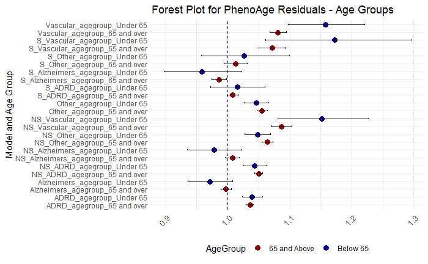

```r
# Forest plot with the renamed age groups
forest_plot_agegroup <- ggplot(filtered_df_agegroup, aes(y = HR, x = as.factor(unique_id))) +
  geom_point(aes(color = AgeGroup), size = 3) +
  geom_errorbar(aes(ymin = CI_lower, ymax = CI_upper), width = 0.2, size = 0.7) +
  geom_hline(yintercept = 1, linetype = "dashed", color = "blue", size = 0.7) +
  scale_color_manual(values = c("Below 65" = "darkblue", "65 and Above" = "darkred")) +
  theme_minimal() +
  labs(title = "Forest Plot for PhenoAge Residuals - Age Groups", y = "Hazard Ratio (HR)", x = "Model and Age Group") +
  coord_flip() +
  theme(legend.position = "bottom",
        axis.text.x = element_text(angle = 45, hjust = 1, size = 10),
        axis.title.x = element_blank())

# Display the plot
forest_plot_agegroup
```

```r
NA
NA
```

Checking separatley

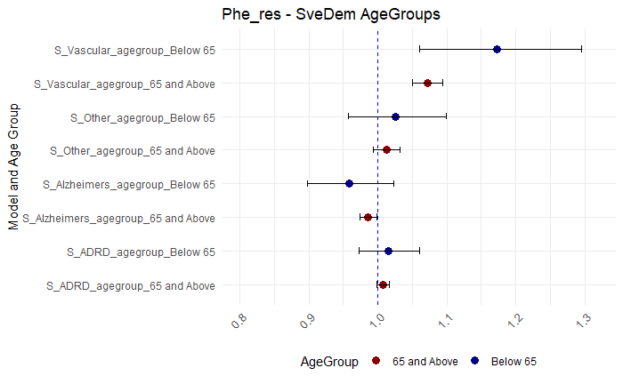

```r
library(ggplot2)
library(dplyr)
library(stringr)

# Renaming the AgeGroup categories and adding a unique row identifier
filtered_df_agegroup <- combined_df_agegroup %>%
  filter(BA == "phenoage_res") %>%
  mutate(AgeGroup = ifelse(AgeGroup == "Under 65", "Below 65", "65 and Above")) %>%
  mutate(unique_id = paste(model, AgeGroup, sep = "_"))

# Filter for models starting with 'S'
models_start_with_S <- filtered_df_agegroup %>%
  filter(str_starts(model, "S"))

# Filter for models starting with 'N'
models_start_with_N <- filtered_df_agegroup %>%
  filter(str_starts(model, "N"))

# Filter for models not starting with 'S' or 'N'
models_not_start_with_SN <- filtered_df_agegroup %>%
  filter(!str_starts(model, "S") & !str_starts(model, "N"))

# Function to create a forest plot
create_forest_plot <- function(data, title_suffix) {
  ggplot(data, aes(y = HR, x = unique_id)) +
    geom_point(aes(color = AgeGroup), size = 3) +
    geom_errorbar(aes(ymin = CI_lower, ymax = CI_upper), width = 0.2, size = 0.7) +
    geom_hline(yintercept = 1, linetype = "dashed", color = "blue", size = 0.7) +
    scale_color_manual(values = c("Below 65" = "darkblue", "65 and Above" = "darkred")) +
    theme_minimal() +
    labs(title = paste("Phe_res -", title_suffix), y = "Hazard Ratio (HR)", x = "Model and Age Group") +
    coord_flip() +
    scale_y_continuous(limits = c(0.8, 1.32)) +
    theme(legend.position = "bottom",
          axis.text.x = element_text(angle = 45, hjust = 1, size = 10),
          axis.title.x = element_blank())
}

# Creating and displaying plots
forest_plot_S <- create_forest_plot(models_start_with_S, "SveDem AgeGroups")
forest_plot_S
```

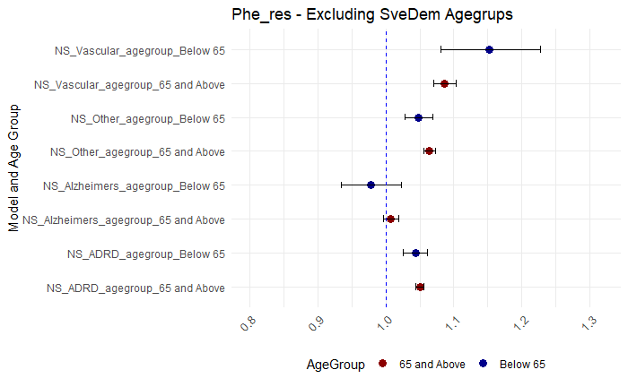

```r
forest_plot_N <- create_forest_plot(models_start_with_N, "Excluding SveDem Agegrups")
forest_plot_N
```

[figure not shown]

```r
forest_plot_Others <- create_forest_plot(models_not_start_with_SN, "All Agegrups")
forest_plot_Others
```

```r
NA
NA
```

## Subgroup gender

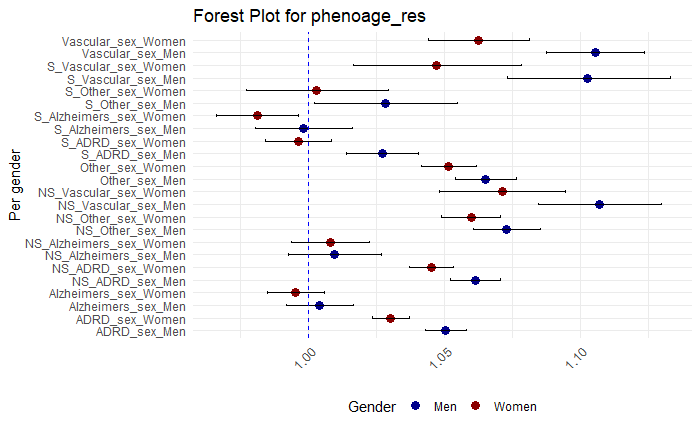

```r
# Add a unique row identifier combining Model and Gender
phenoage_res_gender <- phenoage_res_gender %>%
  mutate(unique_id = paste(model, Gender, sep = "_"))

# Filter for models not starting with 'S'
models_not_start_with_S <- phenoage_res_gender %>%
  filter(!str_starts(model, "S"))

# Enhanced Forest Plot
forest_plot <- ggplot(phenoage_res_gender, aes(y = HR, x = as.factor(unique_id))) +
  geom_point(aes(color = Gender), size = 3) +  # Increase point size
  geom_errorbar(aes(ymin = CI_lower, ymax = CI_upper), width = 0.2, size = 0.7) +  # Adjust error bar size
  geom_hline(yintercept = 1, linetype = "dashed", color = "blue", size = 0.7) +  # Horizontal reference line at HR = 1
  scale_color_manual(values = c("Men" = "darkblue", "Women" = "darkred")) +  # Custom colors for Gender
  theme_minimal() +
  labs(title = "Forest Plot for phenoage_res", y = "Hazard Ratio (HR)", x = "Per gender") +
  coord_flip() +
  theme(legend.position = "bottom",
        axis.text.x = element_text(angle = 45, hjust = 1, size = 10),  # Adjust text angle and size
        axis.title.x = element_blank())
        #panel.grid.major = element_blank(),  # Remove major grid lines
        #panel.grid.minor = element_blank())  # Remove minor grid lines

# Display the enhanced plot
forest_plot
```

Checking separatley

[figure not shown]

```r
library(ggplot2)
library(dplyr)
library(stringr)

#phenoage_res_gender
phenoage_res_gender <- combined_df_gender %>%
  filter(str_detect(BA, "phenoage_res")) %>%
  mutate(unique_id = paste(model, Gender, sep = "_"))

# Filter for models starting with 'S'
models_start_with_S <- phenoage_res_gender %>%
  filter(str_starts(model, "S"))

# Filter for models starting with 'N'
models_start_with_N <- phenoage_res_gender %>%
  filter(str_starts(model, "N"))

# Filter for models not starting with 'S' or 'N'
models_not_start_with_SN <- phenoage_res_gender %>%
  filter(!str_starts(model, "S") & !str_starts(model, "N"))

# Function to create a forest plot
create_forest_plot <- function(data, title_suffix) {
  ggplot(data, aes(y = HR, x = as.factor(unique_id))) +
    geom_point(aes(color = Gender), size = 3) +
    geom_errorbar(aes(ymin = CI_lower, ymax = CI_upper), width = 0.2, size = 0.7) +
    geom_hline(yintercept = 1, linetype = "dashed", color = "blue", size = 0.7) +
    scale_color_manual(values = c("Men" = "darkblue", "Women" = "darkred")) +
    theme_minimal() +
    labs(title = paste("phe_res -", title_suffix), y = "Hazard Ratio (HR)", x = "Model and Gender") +
    coord_flip() +
    scale_y_continuous(limits = c(0.95, 1.15)) +
    theme(legend.position = "bottom",
          axis.text.x = element_text(angle = 45, hjust = 1, size = 10),
          axis.title.x = element_blank())
}

# Creating and displaying plots
forest_plot_S <- create_forest_plot(models_start_with_S, "SveDem per sex")
forest_plot_S
```

[figure not shown]

```r
forest_plot_N <- create_forest_plot(models_start_with_N, "Excluding SveDem per sex")
forest_plot_N
```

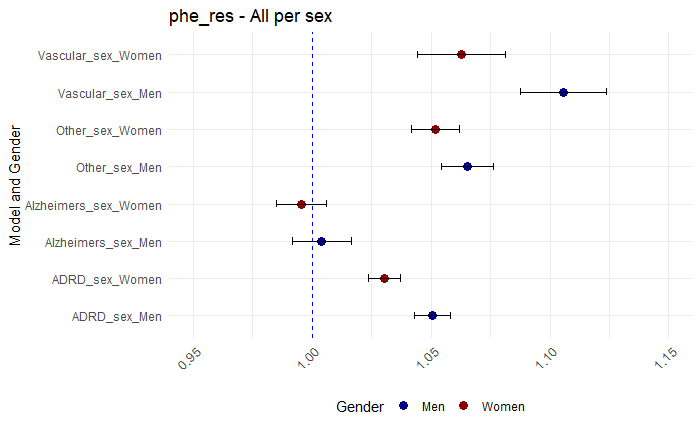

```r
forest_plot_Others <- create_forest_plot(models_not_start_with_SN, "All per sex")
forest_plot_Others
```

p value for stratified groups also make forest plots check age cut off per aim and each results

should I use to1po2 for the association? yes+ since it’s the test data set